# Neighboring COOP stations in the Yampa and Rio Grande areas

Brian

2/7/2023

# Disclaimer

*This work is very preliminary as I get back into the coding swing of things. Data wrangling and figure generation will be done via R, but the rest of the project will be done using good ol’ microsoft products. This is just an entry point into data crunching and should by no means be considered a final product.*

# Coop Data

NOAA/NWS Cooperative Observer Network

For the Yampa area:

STEAMBOAT SPRINGS *CO7936* HAYDEN *CO3867* WALDEN *CO8756* KREMMLING *CO4664* CRAIG 4 SW *CO1932*

For the Rio Grande area:

DEL NORTE 2E *CO2184* HERMIT 7 ESE *CO3951* PAGOSA SPRINGS *CO6258* SILVERTON *CO7656* VALLECITO DAM *CO8582*

Downloading from the [Iowa Environmental Mesonet](https://mesonet.agron.iastate.edu/request/coop/fe.phtml?network=COCLIMATE).

```r
COOP_stations <- read.csv("C:/Users/13074/Documents/ESS580/thesis_project/All_COOP_stations/data_raw/COOP_stations.csv", header = TRUE)

#str(COOP_stations)
```

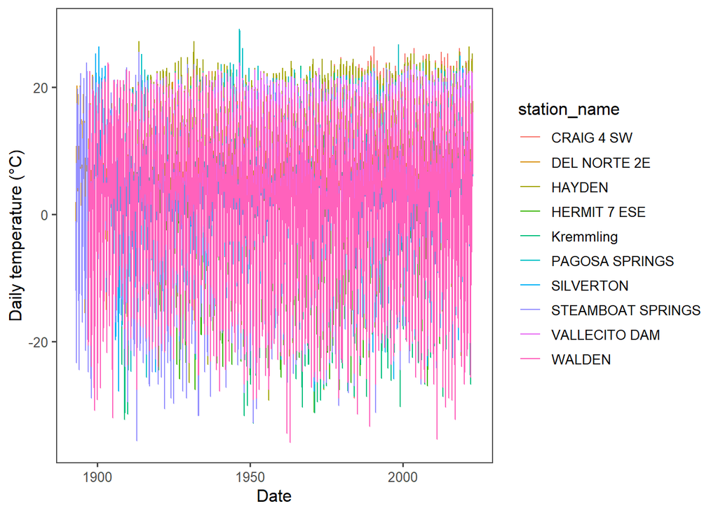

```r
COOP_stations$Date <- ymd(COOP_stations$day)

COOP_stations_clean <- COOP_stations %>% # filter for the timeframe
  addWaterYear() %>%
  mutate(daymonth = format(as.Date(Date), "%d-%m")) %>%
  group_by(waterYear)%>%
  mutate(waterDay = (as.integer(difftime(Date, ymd(paste0(waterYear - 1 ,'-09-30')), units = "days")))) %>%   na.omit()

COOP_stations_clean <- COOP_stations_clean %>%
  mutate(avg_T_c = (highc+lowc)/2) %>%
  filter(waterYear <= 2022)


write.csv(COOP_stations_clean,"C:/Users/13074/Documents/ESS580/thesis_project/All_COOP_stations/data_clean/COOP_stations_clean.csv", row.names = FALSE)

ggplot(COOP_stations_clean, aes(x = Date, y = avg_T_c, color = station_name)) +
  geom_line() + #lwd = 2) +
  theme_few() +
  #geom_smooth(method = "lm", se=FALSE) +
  ylab('Daily temperature (°C)') +
  xlab('Date')
```

```r
# Just checking.
```

# Station methodology

Two stations (Del Norte and Steamboat) will be analyzed for longer spans of time (1900 - 2022), while the remaining stations will be analyzed over the same period of record that the SNOTEL stations operate at (~1980s -2022). Most SNOTEL stations analyzed do not have reliable temperature data before WY 1987 & 1984 in the northern and southern areas respectively. For this purpose we will look at data after WY 1984.

# Standard Deviation

To figure out the standard deviation for each year, I want the “residual” for each daily value.

# Northern Stations

## HAYDEN *CO3867*

Detrending Data

```r
#average water year temperature

CO3867_yearly_wy_aver <- COOP_stations_clean %>%
  filter(station == "CO3867") %>%
  group_by(waterYear) %>%
  filter(waterYear >= 1984) %>%
  mutate(aver_ann_temp = mean(avg_T_c))
```

```r
#Average temperature by day for all water years:

CO3867_daily_wy_aver <- CO3867_yearly_wy_aver %>%
  group_by(daymonth) %>%
  mutate(aver_day_temp = mean(aver_ann_temp))

#average mean temperature by day for the period of record:

CO3867_daily_wy_aver <- CO3867_daily_wy_aver %>%
  group_by(daymonth) %>%
  mutate(all_ave_temp = mean(CO3867_daily_wy_aver$aver_day_temp))

#str(CO3867_daily_wy_aver)
```

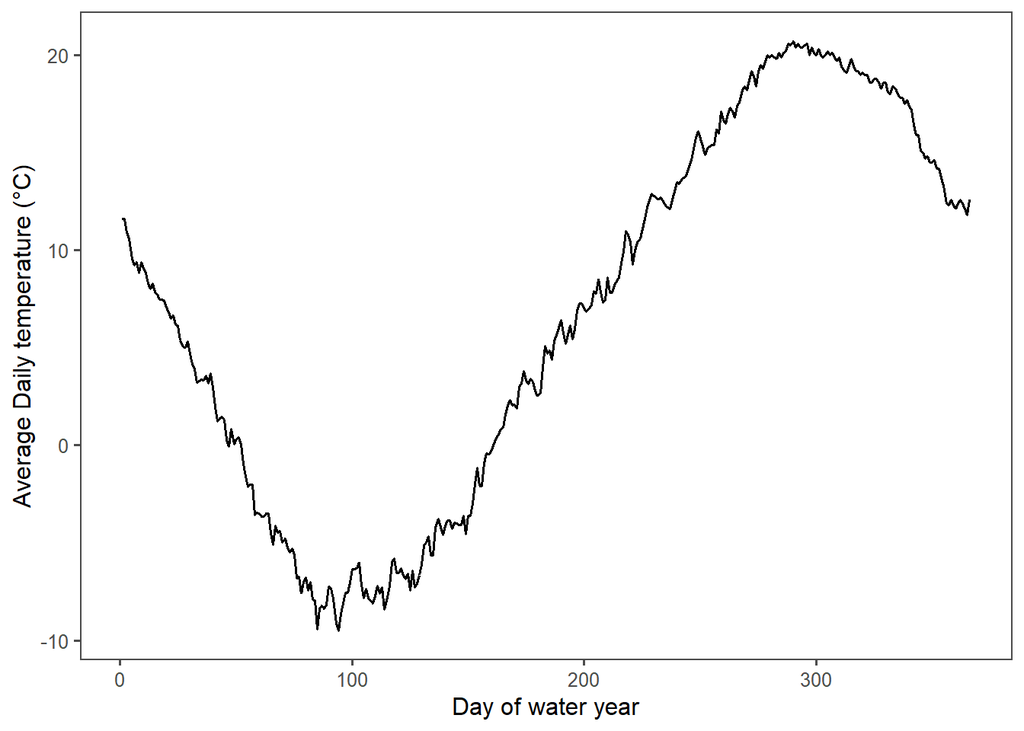

```r
# try to show all years as means.
CO3867_daily_wy_aver2 <- CO3867_daily_wy_aver %>%
  #filter(waterYear == "1987" | waterYear == "2021") %>%
  group_by(waterDay) %>%
  mutate(date_temp = mean(avg_T_c))

CO3867_daily_wy_aver2$date_temp <- signif(CO3867_daily_wy_aver2$date_temp,3) #reduce the sig figs

ggplot(CO3867_daily_wy_aver2, aes(x = waterDay, y = date_temp))+#, color = waterYear)) +
  geom_line(size= 0.7) +
  #geom_line(aes) +
  theme_few() +
  #geom_smooth(method = "lm", se=FALSE) +
  ylab('Average Daily temperature (°C)') +
  xlab('Day of water year')
```

Standard deviation- Determining residuals

```r
CO3867_standard_dev <- CO3867_daily_wy_aver %>%
  group_by(waterYear) %>%
  mutate(residual = (all_ave_temp-aver_ann_temp)+avg_T_c-aver_day_temp) %>%
  mutate(deviation = abs(residual-lag(residual)))

mean(CO3867_standard_dev$residual)
```

```
## [1] -7.446232e-17
```

*The mean of the residuals is close enough to zero*

Calculating standard deviation for the timeseries

```r
CO3867_standard_dev_all <- CO3867_standard_dev %>%
  group_by(waterYear) %>%
  mutate(nmbr = n())

CO3867_standard_dev_all <- CO3867_standard_dev_all %>%
  group_by(waterYear) %>%
  mutate(resid_mean = mean(residual)) %>%
  mutate(sd_1 = residual-resid_mean) %>%
  mutate(sd_2 = (((sum((sd_1)^2))/((nmbr-1))))^(0.5)) %>%
  distinct(sd_2, .keep_all = TRUE) %>%
   select(waterYear, sd_2)

CO3867_standard_dev_all %>%
  kable(.,'html') %>%
  kable_styling() %>%
  scroll_box(width='250px',height='500px')
```

| waterYear | sd_2 |
| --- | --- |
| 1984 | 11.485417 |
| 1985 | 11.180535 |
| 1986 | 9.876778 |
| 1987 | 9.133878 |
| 1988 | 11.008601 |
| 1989 | 11.092140 |
| 1990 | 10.369513 |
| 1991 | 10.739895 |
| 1992 | 10.509582 |
| 1993 | 10.148621 |
| 1994 | 10.680028 |
| 1995 | 9.589489 |
| 1996 | 9.781918 |
| 1997 | 10.480829 |
| 1998 | 9.823480 |
| 1999 | 9.370938 |
| 2000 | 9.464960 |
| 2001 | 11.143631 |
| 2002 | 11.223865 |
| 2003 | 10.221418 |
| 2004 | 9.973747 |
| 2005 | 9.115467 |
| 2006 | 10.817760 |
| 2007 | 11.295537 |
| 2008 | 10.724288 |
| 2009 | 9.396883 |
| 2010 | 10.757495 |
| 2011 | 10.786836 |
| 2012 | 9.858540 |
| 2013 | 11.469037 |
| 2014 | 10.317811 |
| 2015 | 9.518729 |
| 2016 | 10.994901 |
| 2017 | 9.957091 |
| 2018 | 9.664345 |
| 2019 | 10.669019 |
| 2020 | 10.820406 |
| 2021 | 10.982860 |
| 2022 | 10.516975 |

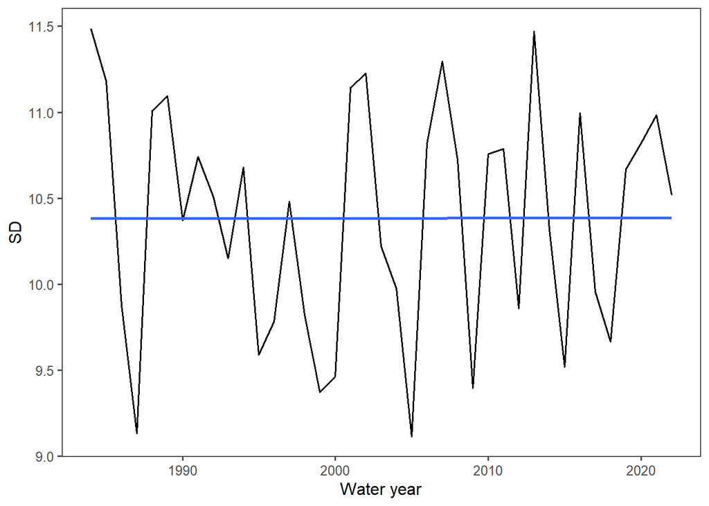

```r
#CALLING THIS something different
CO3867_all_V2 <- ggplot(CO3867_standard_dev_all, aes(x = waterYear, y = sd_2))+
  geom_line(size= 0.7) +
  theme_few() +
  geom_smooth(method = "lm", se=FALSE) +
  ylab('SD') +
  xlab('Water year')


print(CO3867_all_V2)
```

```r
CO3867_sd_mk <- mk.test(CO3867_standard_dev_all$sd_2)
print(CO3867_sd_mk)
```

```
##
##  Mann-Kendall trend test
##
## data:  CO3867_standard_dev_all$sd_2
## z = -0.096775, n = 39, p-value = 0.9229
## alternative hypothesis: true S is not equal to 0
## sample estimates:
##             S          varS           tau
##   -9.00000000 6833.66666667   -0.01214575
```

```r
CO3867_sd_sens <- sens.slope(CO3867_standard_dev_all$sd_2)
print(CO3867_sd_sens)
```

```
##
##  Sen's slope
##
## data:  CO3867_standard_dev_all$sd_2
## z = -0.096775, n = 39, p-value = 0.9229
## alternative hypothesis: true z is not equal to 0
## 95 percent confidence interval:
##  -0.02209965  0.01989011
## sample estimates:
##   Sen's slope
## -0.0007800241
```

Summer temperature standard deviation

```r
CO3867_standard_dev_all_summer <- CO3867_standard_dev %>%
  filter(waterDay >= 244 & waterDay <= 335) %>% # this might be better off as daymonth rather than day of water year due to leap year
  group_by(waterYear) %>%
  mutate(nmbr = n())

CO3867_standard_dev_all_summer <- CO3867_standard_dev_all_summer %>%
  group_by(waterYear) %>%
  mutate(resid_mean = mean(residual)) %>%
  mutate(sd_1 = residual-resid_mean) %>%
  mutate(sd_2 = (((sum((sd_1)^2))/((nmbr-1))))^(0.5)) %>%
  distinct(sd_2, .keep_all = TRUE) %>%
   select(waterYear, sd_2)

CO3867_standard_dev_all_summer %>%
  kable(.,'html') %>%
  kable_styling() %>%
  scroll_box(width='250px',height='500px')
```

| waterYear | sd_2 |
| --- | --- |
| 1984 | 3.618978 |
| 1985 | 2.833661 |
| 1986 | 1.841107 |
| 1987 | 2.301978 |
| 1988 | 2.094272 |
| 1989 | 3.019808 |
| 1990 | 2.776394 |
| 1991 | 2.268129 |
| 1992 | 2.990114 |
| 1993 | 2.697978 |
| 1994 | 2.543786 |
| 1995 | 3.295977 |
| 1996 | 2.378301 |
| 1997 | 2.201010 |
| 1998 | 3.847913 |
| 1999 | 2.605061 |
| 2000 | 2.576684 |
| 2001 | 3.026525 |
| 2002 | 2.742324 |
| 2003 | 3.677107 |
| 2004 | 2.830979 |
| 2005 | 3.705172 |
| 2006 | 2.325716 |
| 2007 | 3.226804 |
| 2008 | 3.564297 |
| 2009 | 2.757671 |
| 2010 | 2.749515 |
| 2011 | 2.736488 |
| 2012 | 2.756577 |
| 2013 | 2.504478 |
| 2014 | 2.697583 |
| 2015 | 2.091126 |
| 2016 | 2.396017 |
| 2017 | 2.530960 |
| 2018 | 2.829001 |
| 2019 | 3.318852 |
| 2020 | 2.939140 |
| 2021 | 3.007404 |
| 2022 | 2.815852 |

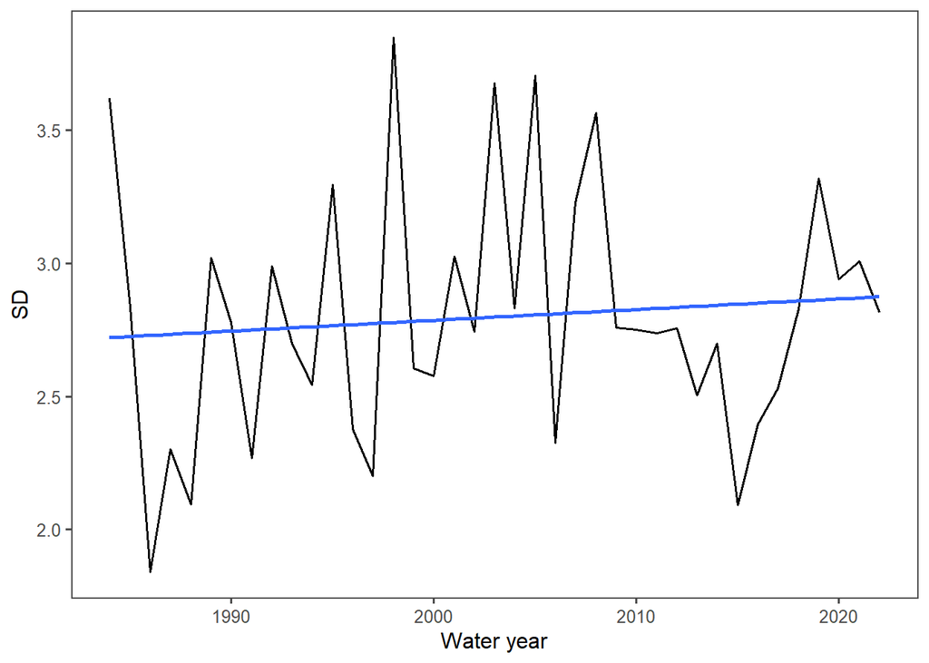

```r
ggplot(CO3867_standard_dev_all_summer, aes(x = waterYear, y = sd_2))+
  geom_line(size= 0.7) +
  theme_few() +
  geom_smooth(method = "lm", se=FALSE) +
  ylab('SD') +
  xlab('Water year')
```

**CO3867 Jun-Aug standard deviation for water years 1984-2022**

Mann-Kendall & Sen’s Slope

Summer standard deviations.

```r
CO3867_sd_mk_summer <- mk.test(CO3867_standard_dev_all_summer$sd_2)
print(CO3867_sd_mk_summer)
```

```
##
##  Mann-Kendall trend test
##
## data:  CO3867_standard_dev_all_summer$sd_2
## z = 0.65323, n = 39, p-value = 0.5136
## alternative hypothesis: true S is not equal to 0
## sample estimates:
##            S         varS          tau
## 5.500000e+01 6.833667e+03 7.422402e-02
```

```r
CO3867_sd_sens_summer <- sens.slope(CO3867_standard_dev_all_summer$sd_2)
print(CO3867_sd_sens_summer)
```

```
##
##  Sen's slope
##
## data:  CO3867_standard_dev_all_summer$sd_2
## z = 0.65323, n = 39, p-value = 0.5136
## alternative hypothesis: true z is not equal to 0
## 95 percent confidence interval:
##  -0.01003205  0.01812277
## sample estimates:
## Sen's slope
##  0.00511551
```

Winter temperature standard deviation

```r
CO3867_standard_dev_all_winter <- CO3867_standard_dev %>%
  filter(waterDay >= 32 & waterDay <= 182) %>% # this might be better off as daymonth rather than day of water year due to leap year
  group_by(waterYear) %>%
  mutate(nmbr = n())

# Nope. This did some weird stuff with twice the observations.
# CO3867_standard_dev_all_winter <- CO3867_standard_dev %>%
#   filter(daymonth >= "01-11" & daymonth <= "31-03") %>%
#   group_by(waterYear) %>%
#   mutate(nmbr = n())


CO3867_standard_dev_all_winter <- CO3867_standard_dev_all_winter %>%
  group_by(waterYear) %>%
  mutate(resid_mean = mean(residual)) %>%
  mutate(sd_1 = residual-resid_mean) %>%
  mutate(sd_2 = (((sum((sd_1)^2))/((nmbr-1))))^(0.5)) %>%
  distinct(sd_2, .keep_all = TRUE) %>%
   select(waterYear, sd_2)

CO3867_standard_dev_all_winter %>%
  kable(.,'html') %>%
  kable_styling() %>%
  scroll_box(width='250px',height='500px')
```

| waterYear | sd_2 |
| --- | --- |
| 1984 | 6.752371 |
| 1985 | 6.992625 |
| 1986 | 7.021863 |
| 1987 | 4.746588 |
| 1988 | 6.458530 |
| 1989 | 7.858157 |
| 1990 | 6.065225 |
| 1991 | 6.992195 |
| 1992 | 6.622718 |
| 1993 | 5.995240 |
| 1994 | 5.966573 |
| 1995 | 5.927126 |
| 1996 | 5.644068 |
| 1997 | 6.264780 |
| 1998 | 4.825588 |
| 1999 | 6.279732 |
| 2000 | 5.566801 |
| 2001 | 5.236716 |
| 2002 | 6.735051 |
| 2003 | 5.328239 |
| 2004 | 6.396353 |
| 2005 | 4.989144 |
| 2006 | 6.367099 |
| 2007 | 7.523509 |
| 2008 | 6.357499 |
| 2009 | 5.844773 |
| 2010 | 6.267521 |
| 2011 | 7.004881 |
| 2012 | 5.213377 |
| 2013 | 7.479074 |
| 2014 | 6.512199 |
| 2015 | 6.697790 |
| 2016 | 6.577107 |
| 2017 | 7.276273 |
| 2018 | 5.600155 |
| 2019 | 5.454007 |
| 2020 | 5.743898 |
| 2021 | 5.775806 |
| 2022 | 6.062583 |

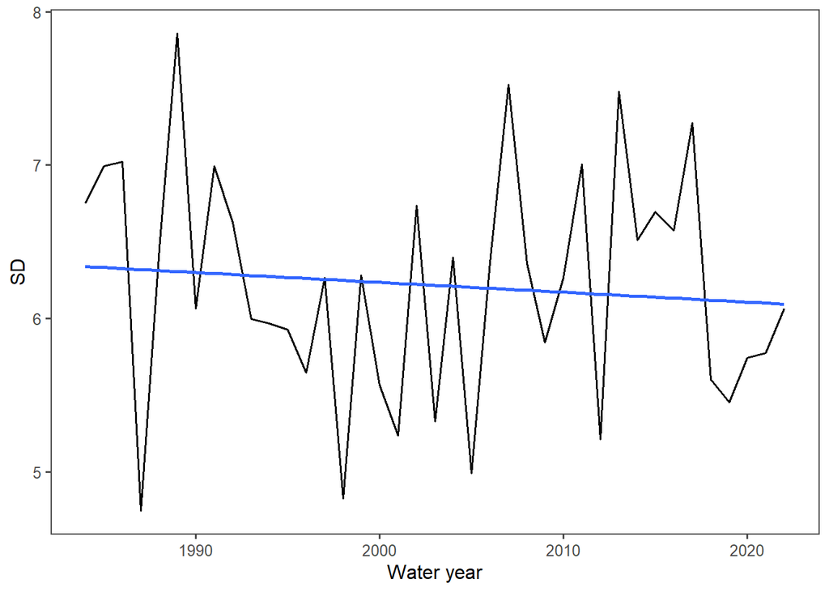

```r
ggplot(CO3867_standard_dev_all_winter, aes(x = waterYear, y = sd_2))+#, color = waterYear)) +
  geom_line(size= 0.7) +
  #geom_line(aes) +
  theme_few() +
  geom_smooth(method = "lm", se=FALSE) +
  ylab('SD') +
  xlab('Water year')
```

**CO3867 Nov-Mar standard deviation for water years 1984-2022**

Mann-Kendall & Sen’s Slope

Winter standard deviations.

```r
CO3867_sd_mk_winter <- mk.test(CO3867_standard_dev_all_winter$sd_2)
print(CO3867_sd_mk_winter)
```

```
##
##  Mann-Kendall trend test
##
## data:  CO3867_standard_dev_all_winter$sd_2
## z = -0.84678, n = 39, p-value = 0.3971
## alternative hypothesis: true S is not equal to 0
## sample estimates:
##             S          varS           tau
##  -71.00000000 6833.66666667   -0.09581646
```

```r
CO3867_sd_sens_winter <- sens.slope(CO3867_standard_dev_all_winter$sd_2)
print(CO3867_sd_sens_winter)
```

```
##
##  Sen's slope
##
## data:  CO3867_standard_dev_all_winter$sd_2
## z = -0.84678, n = 39, p-value = 0.3971
## alternative hypothesis: true z is not equal to 0
## 95 percent confidence interval:
##  -0.03164878  0.01862392
## sample estimates:
##  Sen's slope
## -0.009441259
```

## WALDEN *CO8756*

Detrending Data

```r
#average water year temperature

CO8756_yearly_wy_aver <- COOP_stations_clean %>%
  filter(station == "CO8756") %>%
  group_by(waterYear) %>%
  filter(waterYear >= 1984) %>%
  mutate(aver_ann_temp = mean(avg_T_c))
```

```r
#Average temperature by day for all water years:

CO8756_daily_wy_aver <- CO8756_yearly_wy_aver %>%
  group_by(daymonth) %>%
  mutate(aver_day_temp = mean(aver_ann_temp))

#average mean temperature by day for the period of record:

CO8756_daily_wy_aver <- CO8756_daily_wy_aver %>%
  group_by(daymonth) %>%
  mutate(all_ave_temp = mean(CO8756_daily_wy_aver$aver_day_temp))

#str(CO8756_daily_wy_aver)
```

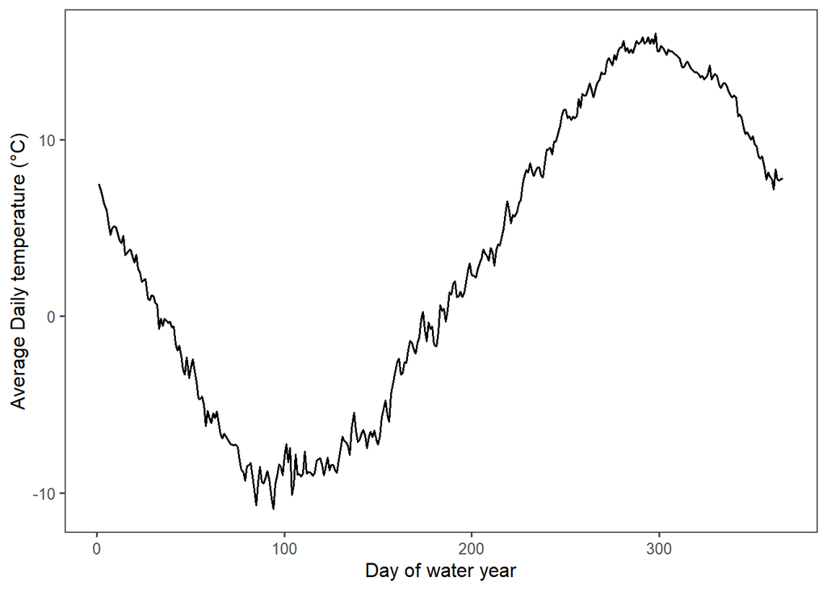

```r
# try to show all years as means.
CO8756_daily_wy_aver2 <- CO8756_daily_wy_aver %>%
  #filter(waterYear == "1987" | waterYear == "2021") %>%
  group_by(waterDay) %>%
  mutate(date_temp = mean(avg_T_c))

CO8756_daily_wy_aver2$date_temp <- signif(CO8756_daily_wy_aver2$date_temp,3) #reduce the sig figs

ggplot(CO8756_daily_wy_aver2, aes(x = waterDay, y = date_temp))+#, color = waterYear)) +
  geom_line(size= 0.7) +
  #geom_line(aes) +
  theme_few() +
  #geom_smooth(method = "lm", se=FALSE) +
  ylab('Average Daily temperature (°C)') +
  xlab('Day of water year')
```

Standard deviation- Determining residuals

```r
CO8756_standard_dev <- CO8756_daily_wy_aver %>%
  group_by(waterYear) %>%
  mutate(residual = (all_ave_temp-aver_ann_temp)+avg_T_c-aver_day_temp) %>%
  mutate(deviation = abs(residual-lag(residual)))

mean(CO8756_standard_dev$residual)
```

```
## [1] 1.497597e-16
```

*The mean of the residuals is close enough to zero*

Calculating standard deviation for the timeseries

```r
CO8756_standard_dev_all <- CO8756_standard_dev %>%
  group_by(waterYear) %>%
  mutate(nmbr = n())

CO8756_standard_dev_all <- CO8756_standard_dev_all %>%
  group_by(waterYear) %>%
  mutate(resid_mean = mean(residual)) %>%
  mutate(sd_1 = residual-resid_mean) %>%
  mutate(sd_2 = (((sum((sd_1)^2))/((nmbr-1))))^(0.5)) %>%
  distinct(sd_2, .keep_all = TRUE) %>%
   select(waterYear, sd_2)

CO8756_standard_dev_all %>%
  kable(.,'html') %>%
  kable_styling() %>%
  scroll_box(width='250px',height='500px')
```

| waterYear | sd_2 |
| --- | --- |
| 1984 | 10.274351 |
| 1985 | 9.525998 |
| 1986 | 8.779071 |
| 1987 | 8.487845 |
| 1988 | 10.339904 |
| 1989 | 9.651614 |
| 1990 | 9.041034 |
| 1991 | 9.094379 |
| 1992 | 8.889496 |
| 1993 | 9.021548 |
| 1994 | 9.472534 |
| 1995 | 8.585995 |
| 1996 | 9.196590 |
| 1997 | 9.540266 |
| 1998 | 9.195245 |
| 1999 | 8.607493 |
| 2000 | 8.580891 |
| 2001 | 9.998693 |
| 2002 | 9.568990 |
| 2003 | 9.169788 |
| 2004 | 9.135617 |
| 2005 | 9.362395 |
| 2006 | 9.918959 |
| 2007 | 10.583525 |
| 2008 | 10.168525 |
| 2009 | 8.515790 |
| 2010 | 10.879203 |
| 2011 | 10.106370 |
| 2012 | 9.301494 |
| 2013 | 10.654885 |
| 2014 | 9.305167 |
| 2015 | 8.952216 |
| 2016 | 10.068499 |
| 2017 | 9.421729 |
| 2018 | 8.417010 |
| 2019 | 9.947851 |
| 2020 | 10.248075 |
| 2021 | 9.934583 |
| 2022 | 10.543226 |

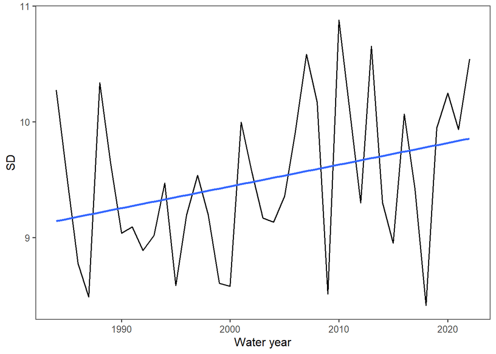

```r
CO8756_all <- ggplot(CO8756_standard_dev_all, aes(x = waterYear, y = sd_2))+
  geom_line(size= 0.7) +
  theme_few() +
  geom_smooth(method = "lm", se=FALSE) +
  ylab('SD') +
  xlab('Water year')

CO8756_all
```

```r
CO8756_sd_mk <- mk.test(CO8756_standard_dev_all$sd_2)
print(CO8756_sd_mk)
```

```
##
##  Mann-Kendall trend test
##
## data:  CO8756_standard_dev_all$sd_2
## z = 1.8629, n = 39, p-value = 0.06247
## alternative hypothesis: true S is not equal to 0
## sample estimates:
##            S         varS          tau
##  155.0000000 6833.6666667    0.2091768
```

```r
CO8756_sd_sens <- sens.slope(CO8756_standard_dev_all$sd_2)
print(CO8756_sd_sens)
```

```
##
##  Sen's slope
##
## data:  CO8756_standard_dev_all$sd_2
## z = 1.8629, n = 39, p-value = 0.06247
## alternative hypothesis: true z is not equal to 0
## 95 percent confidence interval:
##  -0.002285023  0.041751906
## sample estimates:
## Sen's slope
##  0.01980816
```

Summer temperature standard deviation

```r
CO8756_standard_dev_all_summer <- CO8756_standard_dev %>%
  filter(waterDay >= 244 & waterDay <= 335) %>% # this might be better off as daymonth rather than day of water year due to leap year
  group_by(waterYear) %>%
  mutate(nmbr = n())

CO8756_standard_dev_all_summer <- CO8756_standard_dev_all_summer %>%
  group_by(waterYear) %>%
  mutate(resid_mean = mean(residual)) %>%
  mutate(sd_1 = residual-resid_mean) %>%
  mutate(sd_2 = (((sum((sd_1)^2))/((nmbr-1))))^(0.5)) %>%
  distinct(sd_2, .keep_all = TRUE) %>%
   select(waterYear, sd_2)

CO8756_standard_dev_all_summer %>%
  kable(.,'html') %>%
  kable_styling() %>%
  scroll_box(width='250px',height='500px')
```

| waterYear | sd_2 |
| --- | --- |
| 1984 | 3.098045 |
| 1985 | 2.400143 |
| 1986 | 1.746046 |
| 1987 | 2.476687 |
| 1988 | 2.215917 |
| 1989 | 2.831668 |
| 1990 | 2.497958 |
| 1991 | 1.830750 |
| 1992 | 2.688531 |
| 1993 | 2.466431 |
| 1994 | 2.130837 |
| 1995 | 2.887343 |
| 1996 | 2.187068 |
| 1997 | 1.919971 |
| 1998 | 3.590781 |
| 1999 | 2.562795 |
| 2000 | 2.498102 |
| 2001 | 3.070289 |
| 2002 | 2.699482 |
| 2003 | 3.257005 |
| 2004 | 2.445442 |
| 2005 | 3.331090 |
| 2006 | 2.618565 |
| 2007 | 3.150664 |
| 2008 | 3.275320 |
| 2009 | 2.537241 |
| 2010 | 2.571604 |
| 2011 | 2.584250 |
| 2012 | 2.702433 |
| 2013 | 2.595520 |
| 2014 | 2.526453 |
| 2015 | 2.250917 |
| 2016 | 2.303665 |
| 2017 | 2.443964 |
| 2018 | 2.668405 |
| 2019 | 3.050127 |
| 2020 | 2.352849 |
| 2021 | 2.765161 |
| 2022 | 3.145041 |

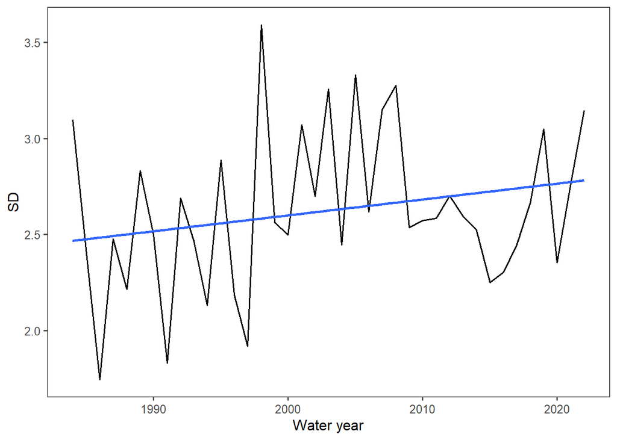

```r
ggplot(CO8756_standard_dev_all_summer, aes(x = waterYear, y = sd_2))+
  geom_line(size= 0.7) +
  theme_few() +
  geom_smooth(method = "lm", se=FALSE) +
  ylab('SD') +
  xlab('Water year')
```

**CO8756 Jun-Aug standard deviation for water years 1984-2022**

Mann-Kendall & Sen’s Slope

Summer standard deviations.

```r
CO8756_sd_mk_summer <- mk.test(CO8756_standard_dev_all_summer$sd_2)
print(CO8756_sd_mk_summer)
```

```
##
##  Mann-Kendall trend test
##
## data:  CO8756_standard_dev_all_summer$sd_2
## z = 1.4032, n = 39, p-value = 0.1605
## alternative hypothesis: true S is not equal to 0
## sample estimates:
##            S         varS          tau
##  117.0000000 6833.6666667    0.1578947
```

```r
CO8756_sd_sens_summer <- sens.slope(CO8756_standard_dev_all_summer$sd_2)
print(CO8756_sd_sens_summer)
```

```
##
##  Sen's slope
##
## data:  CO8756_standard_dev_all_summer$sd_2
## z = 1.4032, n = 39, p-value = 0.1605
## alternative hypothesis: true z is not equal to 0
## 95 percent confidence interval:
##  -0.003752647  0.018993274
## sample estimates:
## Sen's slope
## 0.007350181
```

Winter temperature standard deviation

```r
CO8756_standard_dev_all_winter <- CO8756_standard_dev %>%
  filter(waterDay >= 32 & waterDay <= 182) %>% # this might be better off as daymonth rather than day of water year due to leap year
  group_by(waterYear) %>%
  mutate(nmbr = n())

# Nope. This did some weird stuff with twice the observations.
# CO8756_standard_dev_all_winter <- CO8756_standard_dev %>%
#   filter(daymonth >= "01-11" & daymonth <= "31-03") %>%
#   group_by(waterYear) %>%
#   mutate(nmbr = n())


CO8756_standard_dev_all_winter <- CO8756_standard_dev_all_winter %>%
  group_by(waterYear) %>%
  mutate(resid_mean = mean(residual)) %>%
  mutate(sd_1 = residual-resid_mean) %>%
  mutate(sd_2 = (((sum((sd_1)^2))/((nmbr-1))))^(0.5)) %>%
  distinct(sd_2, .keep_all = TRUE) %>%
   select(waterYear, sd_2)

CO8756_standard_dev_all_winter %>%
  kable(.,'html') %>%
  kable_styling() %>%
  scroll_box(width='250px',height='500px')
```

| waterYear | sd_2 |
| --- | --- |
| 1984 | 6.388216 |
| 1985 | 6.145140 |
| 1986 | 6.192094 |
| 1987 | 4.775302 |
| 1988 | 6.147741 |
| 1989 | 7.299660 |
| 1990 | 5.674100 |
| 1991 | 5.806674 |
| 1992 | 5.383528 |
| 1993 | 5.497675 |
| 1994 | 5.335567 |
| 1995 | 5.625263 |
| 1996 | 6.227290 |
| 1997 | 6.355164 |
| 1998 | 4.852754 |
| 1999 | 5.892465 |
| 2000 | 5.410936 |
| 2001 | 5.139805 |
| 2002 | 5.879976 |
| 2003 | 5.478155 |
| 2004 | 6.577846 |
| 2005 | 5.799475 |
| 2006 | 6.730566 |
| 2007 | 8.012348 |
| 2008 | 6.720676 |
| 2009 | 5.728422 |
| 2010 | 7.020769 |
| 2011 | 7.094309 |
| 2012 | 5.681759 |
| 2013 | 7.926274 |
| 2014 | 5.973882 |
| 2015 | 7.409992 |
| 2016 | 7.063565 |
| 2017 | 7.624513 |
| 2018 | 5.533485 |
| 2019 | 5.538138 |
| 2020 | 6.860450 |
| 2021 | 5.784767 |
| 2022 | 7.619323 |

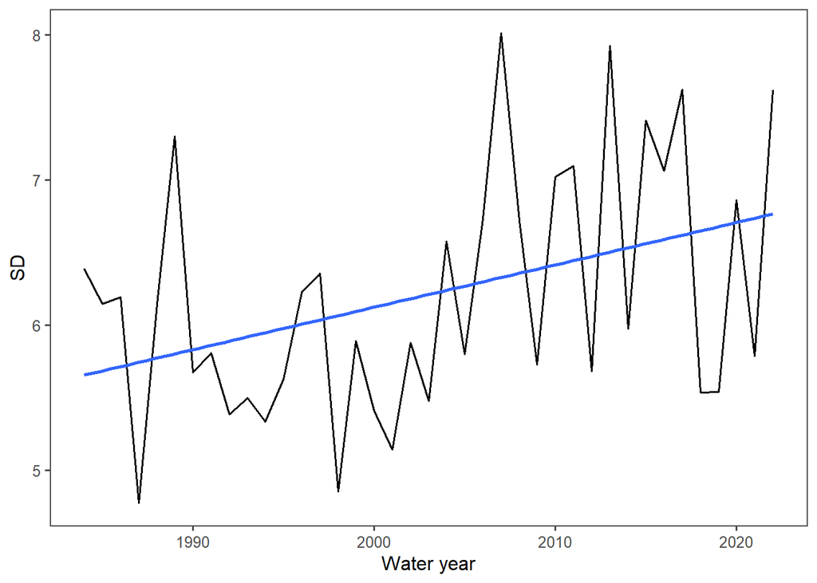

```r
ggplot(CO8756_standard_dev_all_winter, aes(x = waterYear, y = sd_2))+#, color = waterYear)) +
  geom_line(size= 0.7) +
  #geom_line(aes) +
  theme_few() +
  geom_smooth(method = "lm", se=FALSE) +
  ylab('SD') +
  xlab('Water year')
```

**CO8756 Nov-Mar standard deviation for water years 1984-2022**

Mann-Kendall & Sen’s Slope

Winter standard deviations.

```r
CO8756_sd_mk_winter <- mk.test(CO8756_standard_dev_all_winter$sd_2)
print(CO8756_sd_mk_winter)
```

```
##
##  Mann-Kendall trend test
##
## data:  CO8756_standard_dev_all_winter$sd_2
## z = 2.129, n = 39, p-value = 0.03325
## alternative hypothesis: true S is not equal to 0
## sample estimates:
##            S         varS          tau
##  177.0000000 6833.6666667    0.2388664
```

```r
CO8756_sd_sens_winter <- sens.slope(CO8756_standard_dev_all_winter$sd_2)
print(CO8756_sd_sens_winter)
```

```
##
##  Sen's slope
##
## data:  CO8756_standard_dev_all_winter$sd_2
## z = 2.129, n = 39, p-value = 0.03325
## alternative hypothesis: true z is not equal to 0
## 95 percent confidence interval:
##  0.003425964 0.056677063
## sample estimates:
## Sen's slope
##  0.02683425
```

## KREMMLING *CO4664*

Detrending Data

```r
#average water year temperature

CO4664_yearly_wy_aver <- COOP_stations_clean %>%
  filter(station == "CO4664") %>%
  group_by(waterYear) %>%
  filter(waterYear >= 1984) %>%
  mutate(aver_ann_temp = mean(avg_T_c))
```

```r
#Average temperature by day for all water years:

CO4664_daily_wy_aver <- CO4664_yearly_wy_aver %>%
  group_by(daymonth) %>%
  mutate(aver_day_temp = mean(aver_ann_temp))

#average mean temperature by day for the period of record:

CO4664_daily_wy_aver <- CO4664_daily_wy_aver %>%
  group_by(daymonth) %>%
  mutate(all_ave_temp = mean(CO4664_daily_wy_aver$aver_day_temp))

#str(CO4664_daily_wy_aver)
```

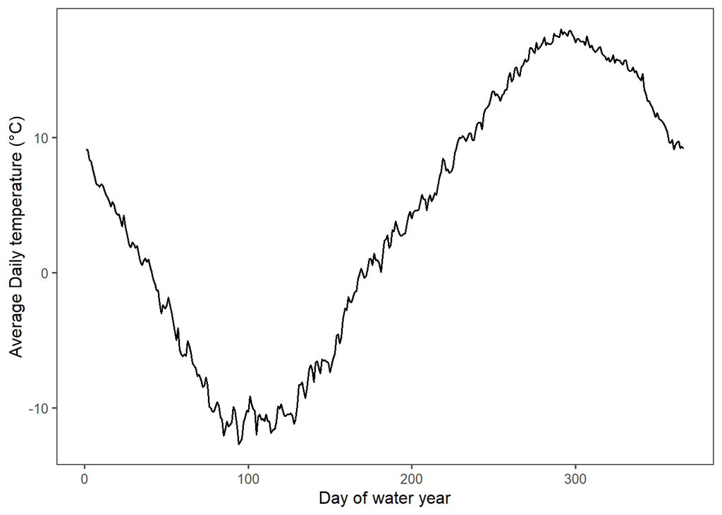

```r
# try to show all years as means.
CO4664_daily_wy_aver2 <- CO4664_daily_wy_aver %>%
  #filter(waterYear == "1987" | waterYear == "2021") %>%
  group_by(waterDay) %>%
  mutate(date_temp = mean(avg_T_c))

CO4664_daily_wy_aver2$date_temp <- signif(CO4664_daily_wy_aver2$date_temp,3) #reduce the sig figs

ggplot(CO4664_daily_wy_aver2, aes(x = waterDay, y = date_temp))+#, color = waterYear)) +
  geom_line(size= 0.7) +
  #geom_line(aes) +
  theme_few() +
  #geom_smooth(method = "lm", se=FALSE) +
  ylab('Average Daily temperature (°C)') +
  xlab('Day of water year')
```

Standard deviation- Determining residuals

```r
CO4664_standard_dev <- CO4664_daily_wy_aver %>%
  group_by(waterYear) %>%
  mutate(residual = (all_ave_temp-aver_ann_temp)+avg_T_c-aver_day_temp) %>%
  mutate(deviation = abs(residual-lag(residual)))

mean(CO4664_standard_dev$residual)
```

```
## [1] -1.49728e-16
```

*The mean of the residuals is close enough to zero*

Calculating standard deviation for the timeseries

```r
CO4664_standard_dev_all <- CO4664_standard_dev %>%
  group_by(waterYear) %>%
  mutate(nmbr = n())

CO4664_standard_dev_all <- CO4664_standard_dev_all %>%
  group_by(waterYear) %>%
  mutate(resid_mean = mean(residual)) %>%
  mutate(sd_1 = residual-resid_mean) %>%
  mutate(sd_2 = (((sum((sd_1)^2))/((nmbr-1))))^(0.5)) %>%
  distinct(sd_2, .keep_all = TRUE) %>%
   select(waterYear, sd_2)

CO4664_standard_dev_all %>%
  kable(.,'html') %>%
  kable_styling() %>%
  scroll_box(width='250px',height='500px')
```

| waterYear | sd_2 |
| --- | --- |
| 1984 | 11.842808 |
| 1985 | 10.534290 |
| 1986 | 10.076518 |
| 1987 | 9.278036 |
| 1988 | 11.625055 |
| 1989 | 9.347699 |
| 1990 | 8.896884 |
| 1991 | 11.059919 |
| 1992 | 10.593674 |
| 1993 | 11.082078 |
| 1994 | 10.858112 |
| 1995 | 10.294300 |
| 1996 | 10.772898 |
| 1997 | 10.417175 |
| 1998 | 10.004330 |
| 1999 | 9.816385 |
| 2000 | 9.827327 |
| 2001 | 11.308940 |
| 2002 | 11.334081 |
| 2003 | 10.241340 |
| 2004 | 9.836909 |
| 2005 | 10.949455 |
| 2006 | 11.325117 |
| 2007 | 11.322739 |
| 2008 | 11.113829 |
| 2009 | 9.570323 |
| 2010 | 11.562640 |
| 2011 | 10.555622 |
| 2012 | 10.157042 |
| 2013 | 12.623254 |
| 2014 | 10.708303 |
| 2015 | 9.799999 |
| 2016 | 11.086904 |
| 2017 | 9.803356 |
| 2018 | 9.386863 |
| 2019 | 10.644464 |
| 2020 | 11.277542 |
| 2021 | 10.570883 |
| 2022 | 12.052823 |

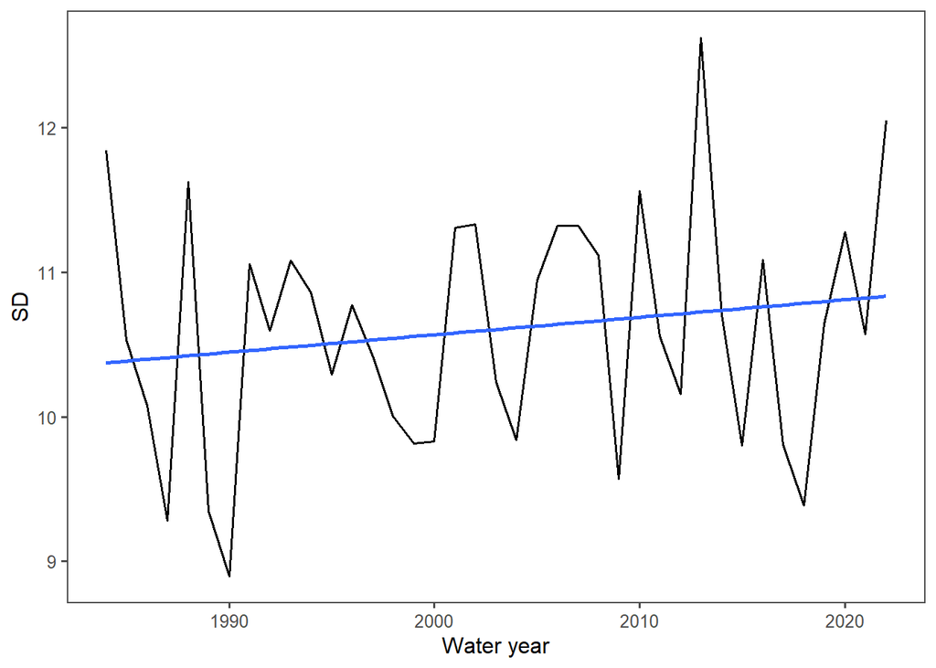

```r
ggplot(CO4664_standard_dev_all, aes(x = waterYear, y = sd_2))+
  geom_line(size= 0.7) +
  theme_few() +
  geom_smooth(method = "lm", se=FALSE) +
  ylab('SD') +
  xlab('Water year')
```

```r
CO4664_sd_mk <- mk.test(CO4664_standard_dev_all$sd_2)
print(CO4664_sd_mk)
```

```
##
##  Mann-Kendall trend test
##
## data:  CO4664_standard_dev_all$sd_2
## z = 0.65323, n = 39, p-value = 0.5136
## alternative hypothesis: true S is not equal to 0
## sample estimates:
##            S         varS          tau
## 5.500000e+01 6.833667e+03 7.422402e-02
```

```r
CO4664_sd_sens <- sens.slope(CO4664_standard_dev_all$sd_2)
print(CO4664_sd_sens)
```

```
##
##  Sen's slope
##
## data:  CO4664_standard_dev_all$sd_2
## z = 0.65323, n = 39, p-value = 0.5136
## alternative hypothesis: true z is not equal to 0
## 95 percent confidence interval:
##  -0.01825695  0.03598021
## sample estimates:
## Sen's slope
##  0.01033134
```

Summer temperature standard deviation

```r
CO4664_standard_dev_all_summer <- CO4664_standard_dev %>%
  filter(waterDay >= 244 & waterDay <= 335) %>% # this might be better off as daymonth rather than day of water year due to leap year
  group_by(waterYear) %>%
  mutate(nmbr = n())

CO4664_standard_dev_all_summer <- CO4664_standard_dev_all_summer %>%
  group_by(waterYear) %>%
  mutate(resid_mean = mean(residual)) %>%
  mutate(sd_1 = residual-resid_mean) %>%
  mutate(sd_2 = (((sum((sd_1)^2))/((nmbr-1))))^(0.5)) %>%
  distinct(sd_2, .keep_all = TRUE) %>%
   select(waterYear, sd_2)

CO4664_standard_dev_all_summer %>%
  kable(.,'html') %>%
  kable_styling() %>%
  scroll_box(width='250px',height='500px')
```

| waterYear | sd_2 |
| --- | --- |
| 1984 | 3.215574 |
| 1985 | 2.475205 |
| 1986 | 2.101595 |
| 1987 | 2.347529 |
| 1988 | 2.200798 |
| 1989 | 2.800050 |
| 1990 | 2.226887 |
| 1991 | 2.076735 |
| 1992 | 2.867749 |
| 1993 | 2.776034 |
| 1994 | 2.281763 |
| 1995 | 3.141926 |
| 1996 | 2.314091 |
| 1997 | 2.451858 |
| 1998 | 3.543159 |
| 1999 | 2.878018 |
| 2000 | 2.506292 |
| 2001 | 3.257659 |
| 2002 | 2.660263 |
| 2003 | 3.268403 |
| 2004 | 3.015509 |
| 2005 | 3.361711 |
| 2006 | 2.706764 |
| 2007 | 3.234749 |
| 2008 | 3.284052 |
| 2009 | 2.592534 |
| 2010 | 2.867244 |
| 2011 | 2.701616 |
| 2012 | 2.305239 |
| 2013 | 2.744107 |
| 2014 | 2.749757 |
| 2015 | 2.245707 |
| 2016 | 2.532862 |
| 2017 | 2.363437 |
| 2018 | 2.522825 |
| 2019 | 3.257400 |
| 2020 | 2.507018 |
| 2021 | 2.477895 |
| 2022 | 2.912039 |

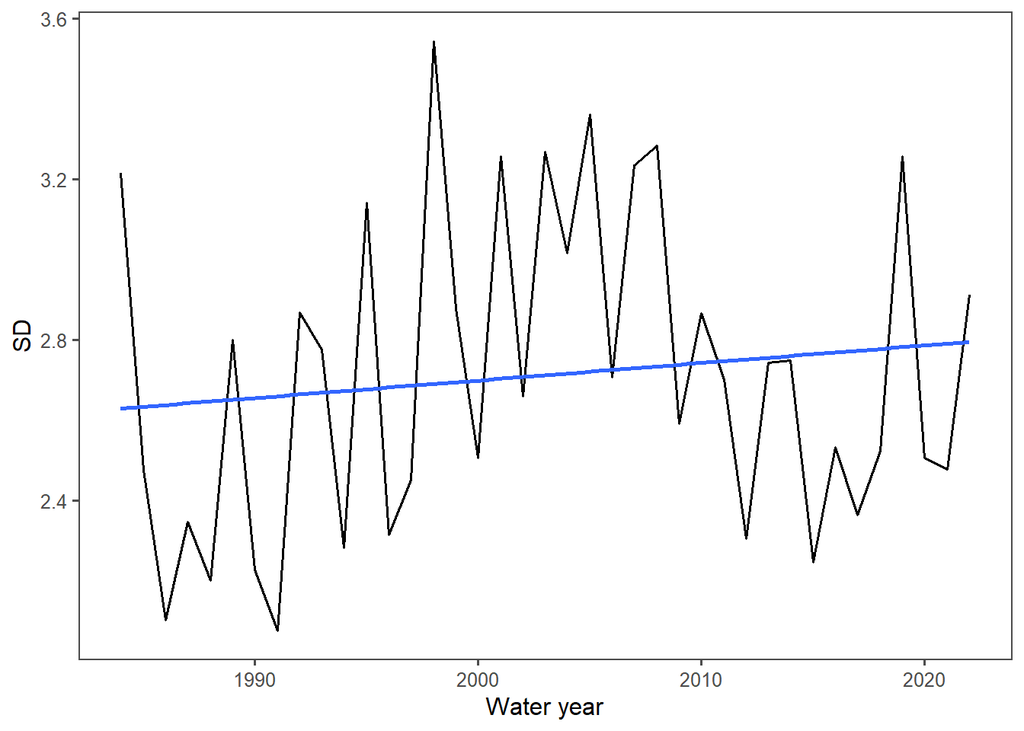

```r
ggplot(CO4664_standard_dev_all_summer, aes(x = waterYear, y = sd_2))+
  geom_line(size= 0.7) +
  theme_few() +
  geom_smooth(method = "lm", se=FALSE) +
  ylab('SD') +
  xlab('Water year')
```

**CO4664 Jun-Aug standard deviation for water years 1984-2022**

Mann-Kendall & Sen’s Slope

Summer standard deviations.

```r
CO4664_sd_mk_summer <- mk.test(CO4664_standard_dev_all_summer$sd_2)
print(CO4664_sd_mk_summer)
```

```
##
##  Mann-Kendall trend test
##
## data:  CO4664_standard_dev_all_summer$sd_2
## z = 0.87097, n = 39, p-value = 0.3838
## alternative hypothesis: true S is not equal to 0
## sample estimates:
##            S         varS          tau
## 7.300000e+01 6.833667e+03 9.851552e-02
```

```r
CO4664_sd_sens_summer <- sens.slope(CO4664_standard_dev_all_summer$sd_2)
print(CO4664_sd_sens_summer)
```

```
##
##  Sen's slope
##
## data:  CO4664_standard_dev_all_summer$sd_2
## z = 0.87097, n = 39, p-value = 0.3838
## alternative hypothesis: true z is not equal to 0
## 95 percent confidence interval:
##  -0.008550703  0.017390398
## sample estimates:
## Sen's slope
## 0.004689828
```

Winter temperature standard deviation

```r
CO4664_standard_dev_all_winter <- CO4664_standard_dev %>%
  filter(waterDay >= 32 & waterDay <= 182) %>% # this might be better off as daymonth rather than day of water year due to leap year
  group_by(waterYear) %>%
  mutate(nmbr = n())

# Nope. This did some weird stuff with twice the observations.
# CO4664_standard_dev_all_winter <- CO4664_standard_dev %>%
#   filter(daymonth >= "01-11" & daymonth <= "31-03") %>%
#   group_by(waterYear) %>%
#   mutate(nmbr = n())


CO4664_standard_dev_all_winter <- CO4664_standard_dev_all_winter %>%
  group_by(waterYear) %>%
  mutate(resid_mean = mean(residual)) %>%
  mutate(sd_1 = residual-resid_mean) %>%
  mutate(sd_2 = (((sum((sd_1)^2))/((nmbr-1))))^(0.5)) %>%
  distinct(sd_2, .keep_all = TRUE) %>%
   select(waterYear, sd_2)

CO4664_standard_dev_all_winter %>%
  kable(.,'html') %>%
  kable_styling() %>%
  scroll_box(width='250px',height='500px')
```

| waterYear | sd_2 |
| --- | --- |
| 1984 | 8.415912 |
| 1985 | 6.582282 |
| 1986 | 7.474738 |
| 1987 | 5.125150 |
| 1988 | 7.328129 |
| 1989 | 6.353786 |
| 1990 | 4.920860 |
| 1991 | 7.488192 |
| 1992 | 6.831213 |
| 1993 | 6.969575 |
| 1994 | 6.705696 |
| 1995 | 7.240966 |
| 1996 | 7.611583 |
| 1997 | 7.031740 |
| 1998 | 5.434719 |
| 1999 | 7.362196 |
| 2000 | 5.892683 |
| 2001 | 6.231018 |
| 2002 | 7.028370 |
| 2003 | 5.938219 |
| 2004 | 7.200707 |
| 2005 | 7.097081 |
| 2006 | 7.531862 |
| 2007 | 7.995449 |
| 2008 | 6.745011 |
| 2009 | 6.431922 |
| 2010 | 7.100432 |
| 2011 | 7.036948 |
| 2012 | 5.800580 |
| 2013 | 9.665351 |
| 2014 | 7.332683 |
| 2015 | 6.994797 |
| 2016 | 7.667858 |
| 2017 | 7.713234 |
| 2018 | 5.787009 |
| 2019 | 5.846507 |
| 2020 | 7.142392 |
| 2021 | 5.555605 |
| 2022 | 8.574035 |

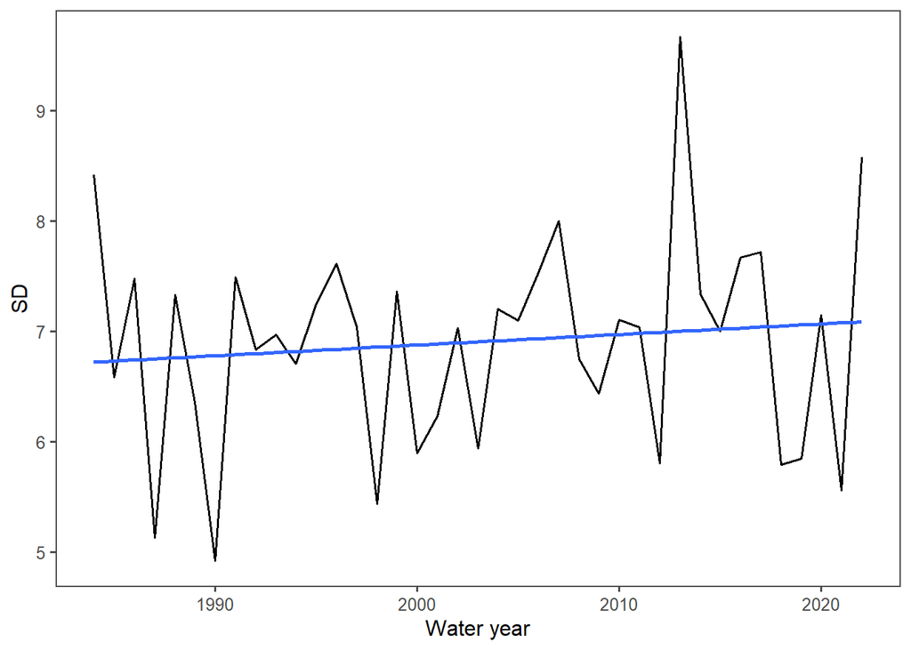

```r
ggplot(CO4664_standard_dev_all_winter, aes(x = waterYear, y = sd_2))+#, color = waterYear)) +
  geom_line(size= 0.7) +
  #geom_line(aes) +
  theme_few() +
  geom_smooth(method = "lm", se=FALSE) +
  ylab('SD') +
  xlab('Water year')
```

**CO4664 Nov-Mar standard deviation for water years 1984-2022**

Mann-Kendall & Sen’s Slope

Winter standard deviations.

```r
CO4664_sd_mk_winter <- mk.test(CO4664_standard_dev_all_winter$sd_2)
print(CO4664_sd_mk_winter)
```

```
##
##  Mann-Kendall trend test
##
## data:  CO4664_standard_dev_all_winter$sd_2
## z = 0.55646, n = 39, p-value = 0.5779
## alternative hypothesis: true S is not equal to 0
## sample estimates:
##            S         varS          tau
##   47.0000000 6833.6666667    0.0634278
```

```r
CO4664_sd_sens_winter <- sens.slope(CO4664_standard_dev_all_winter$sd_2)
print(CO4664_sd_sens_winter)
```

```
##
##  Sen's slope
##
## data:  CO4664_standard_dev_all_winter$sd_2
## z = 0.55646, n = 39, p-value = 0.5779
## alternative hypothesis: true z is not equal to 0
## 95 percent confidence interval:
##  -0.02129328  0.03407467
## sample estimates:
## Sen's slope
## 0.006437321
```

## CRAIG 4 SW *CO1932*

Detrending Data

```r
#average water year temperature

CO1932_yearly_wy_aver <- COOP_stations_clean %>%
  filter(station == "CO1932") %>%
  group_by(waterYear) %>%
  filter(waterYear >= 1984) %>%
  mutate(aver_ann_temp = mean(avg_T_c))
```

```r
#Average temperature by day for all water years:

CO1932_daily_wy_aver <- CO1932_yearly_wy_aver %>%
  group_by(daymonth) %>%
  mutate(aver_day_temp = mean(aver_ann_temp))

#average mean temperature by day for the period of record:

CO1932_daily_wy_aver <- CO1932_daily_wy_aver %>%
  group_by(daymonth) %>%
  mutate(all_ave_temp = mean(CO1932_daily_wy_aver$aver_day_temp))

#str(CO1932_daily_wy_aver)
```

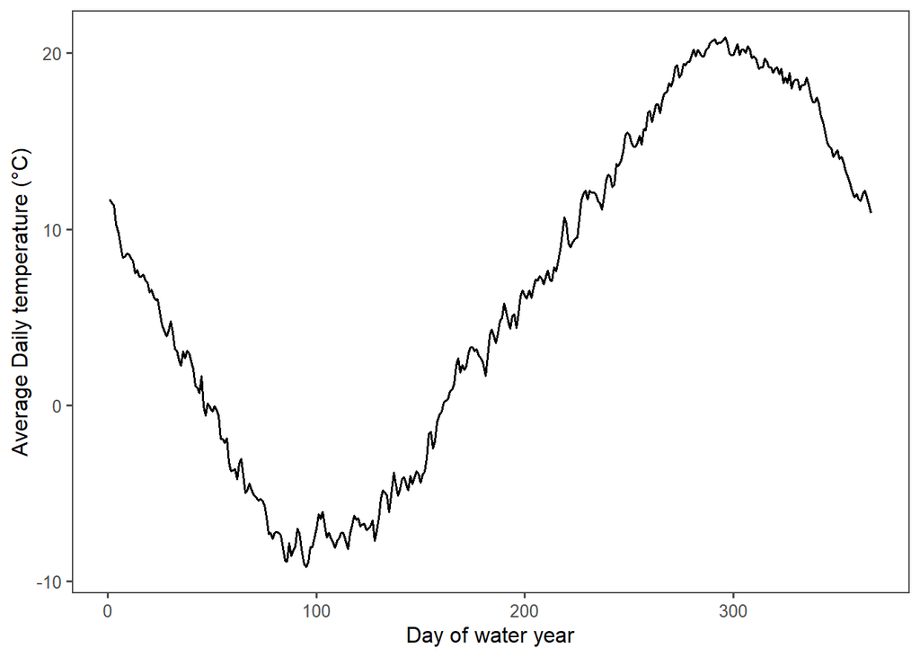

```r
# try to show all years as means.
CO1932_daily_wy_aver2 <- CO1932_daily_wy_aver %>%
  #filter(waterYear == "1987" | waterYear == "2021") %>%
  group_by(waterDay) %>%
  mutate(date_temp = mean(avg_T_c))

CO1932_daily_wy_aver2$date_temp <- signif(CO1932_daily_wy_aver2$date_temp,3) #reduce the sig figs

ggplot(CO1932_daily_wy_aver2, aes(x = waterDay, y = date_temp))+#, color = waterYear)) +
  geom_line(size= 0.7) +
  #geom_line(aes) +
  theme_few() +
  #geom_smooth(method = "lm", se=FALSE) +
  ylab('Average Daily temperature (°C)') +
  xlab('Day of water year')
```

Standard deviation- Determining residuals

```r
CO1932_standard_dev <- CO1932_daily_wy_aver %>%
  group_by(waterYear) %>%
  mutate(residual = (all_ave_temp-aver_ann_temp)+avg_T_c-aver_day_temp) %>%
  mutate(deviation = abs(residual-lag(residual)))

mean(CO1932_standard_dev$residual)
```

```
## [1] -8.879044e-17
```

*The mean of the residuals is close enough to zero*

Calculating standard deviation for the timeseries

```r
CO1932_standard_dev_all <- CO1932_standard_dev %>%
  group_by(waterYear) %>%
  mutate(nmbr = n())

CO1932_standard_dev_all <- CO1932_standard_dev_all %>%
  group_by(waterYear) %>%
  mutate(resid_mean = mean(residual)) %>%
  mutate(sd_1 = residual-resid_mean) %>%
  mutate(sd_2 = (((sum((sd_1)^2))/((nmbr-1))))^(0.5)) %>%
  distinct(sd_2, .keep_all = TRUE) %>%
   select(waterYear, sd_2)

CO1932_standard_dev_all %>%
  kable(.,'html') %>%
  kable_styling() %>%
  scroll_box(width='250px',height='500px')
```

| waterYear | sd_2 |
| --- | --- |
| 1984 | 11.488319 |
| 1985 | 11.455082 |
| 1986 | 9.864992 |
| 1987 | 9.585951 |
| 1988 | 11.246784 |
| 1989 | 11.555146 |
| 1990 | 10.344382 |
| 1991 | 10.858624 |
| 1992 | 10.472265 |
| 1993 | 10.301132 |
| 1994 | 10.536316 |
| 1995 | 9.310312 |
| 1996 | 9.544994 |
| 1997 | 10.099325 |
| 1998 | 9.847825 |
| 1999 | 9.088993 |
| 2000 | 9.304220 |
| 2001 | 11.005474 |
| 2002 | 11.289134 |
| 2003 | 9.843375 |
| 2004 | 10.103283 |
| 2005 | 8.954807 |
| 2006 | 10.204469 |
| 2007 | 11.470209 |
| 2008 | 10.986494 |
| 2009 | 9.784410 |
| 2010 | 10.911922 |
| 2011 | 10.981962 |
| 2012 | 10.280547 |
| 2013 | 11.815300 |
| 2014 | 10.513937 |
| 2015 | 9.749572 |
| 2016 | 11.080780 |
| 2017 | 10.244804 |
| 2018 | 9.882973 |
| 2019 | 10.893427 |
| 2020 | 11.218502 |
| 2021 | 11.125873 |
| 2022 | 11.083751 |

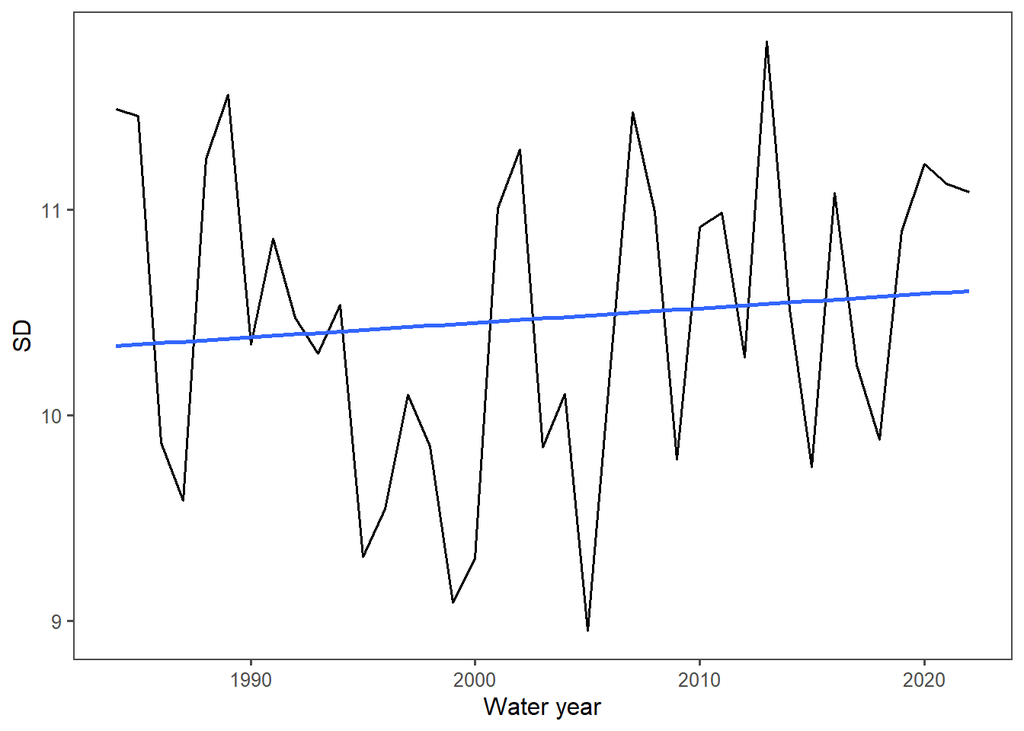

```r
ggplot(CO1932_standard_dev_all, aes(x = waterYear, y = sd_2))+
  geom_line(size= 0.7) +
  theme_few() +
  geom_smooth(method = "lm", se=FALSE) +
  ylab('SD') +
  xlab('Water year')
```

```r
CO1932_sd_mk <- mk.test(CO1932_standard_dev_all$sd_2)
print(CO1932_sd_mk)
```

```
##
##  Mann-Kendall trend test
##
## data:  CO1932_standard_dev_all$sd_2
## z = 0.45968, n = 39, p-value = 0.6457
## alternative hypothesis: true S is not equal to 0
## sample estimates:
##            S         varS          tau
## 3.900000e+01 6.833667e+03 5.263158e-02
```

```r
CO1932_sd_sens <- sens.slope(CO1932_standard_dev_all$sd_2)
print(CO1932_sd_sens)
```

```
##
##  Sen's slope
##
## data:  CO1932_standard_dev_all$sd_2
## z = 0.45968, n = 39, p-value = 0.6457
## alternative hypothesis: true z is not equal to 0
## 95 percent confidence interval:
##  -0.01573645  0.03213936
## sample estimates:
## Sen's slope
## 0.007273959
```

Summer temperature standard deviation

```r
CO1932_standard_dev_all_summer <- CO1932_standard_dev %>%
  filter(waterDay >= 244 & waterDay <= 335) %>% # this might be better off as daymonth rather than day of water year due to leap year
  group_by(waterYear) %>%
  mutate(nmbr = n())

CO1932_standard_dev_all_summer <- CO1932_standard_dev_all_summer %>%
  group_by(waterYear) %>%
  mutate(resid_mean = mean(residual)) %>%
  mutate(sd_1 = residual-resid_mean) %>%
  mutate(sd_2 = (((sum((sd_1)^2))/((nmbr-1))))^(0.5)) %>%
  distinct(sd_2, .keep_all = TRUE) %>%
   select(waterYear, sd_2)

CO1932_standard_dev_all_summer %>%
  kable(.,'html') %>%
  kable_styling() %>%
  scroll_box(width='250px',height='500px')
```

| waterYear | sd_2 |
| --- | --- |
| 1984 | 3.771767 |
| 1985 | 3.061372 |
| 1986 | 2.236917 |
| 1987 | 2.755026 |
| 1988 | 2.923342 |
| 1989 | 3.447128 |
| 1990 | 3.285824 |
| 1991 | 2.610959 |
| 1992 | 3.341025 |
| 1993 | 3.172880 |
| 1994 | 2.326110 |
| 1995 | 3.346459 |
| 1996 | 2.373395 |
| 1997 | 2.402126 |
| 1998 | 4.132837 |
| 1999 | 2.823431 |
| 2000 | 2.788161 |
| 2001 | 3.157886 |
| 2002 | 2.983087 |
| 2003 | 3.610345 |
| 2004 | 3.041601 |
| 2005 | 3.984741 |
| 2006 | 2.667119 |
| 2007 | 3.620785 |
| 2008 | 4.106893 |
| 2009 | 3.096088 |
| 2010 | 3.127090 |
| 2011 | 3.104357 |
| 2012 | 2.684607 |
| 2013 | 2.760181 |
| 2014 | 3.435432 |
| 2015 | 2.536963 |
| 2016 | 2.475548 |
| 2017 | 2.685470 |
| 2018 | 3.126233 |
| 2019 | 3.602189 |
| 2020 | 3.309112 |
| 2021 | 2.950159 |
| 2022 | 3.367256 |

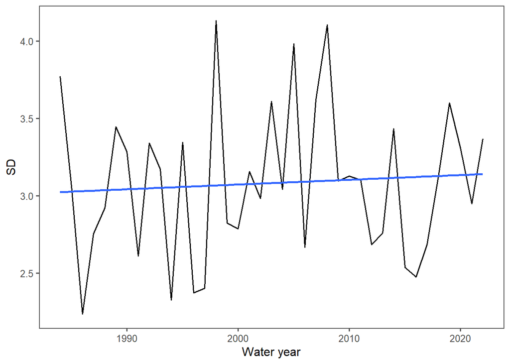

```r
ggplot(CO1932_standard_dev_all_summer, aes(x = waterYear, y = sd_2))+
  geom_line(size= 0.7) +
  theme_few() +
  geom_smooth(method = "lm", se=FALSE) +
  ylab('SD') +
  xlab('Water year')
```

**CO1932 Jun-Aug standard deviation for water years 1984-2022**

Mann-Kendall & Sen’s Slope

Summer standard deviations.

```r
CO1932_sd_mk_summer <- mk.test(CO1932_standard_dev_all_summer$sd_2)
print(CO1932_sd_mk_summer)
```

```
##
##  Mann-Kendall trend test
##
## data:  CO1932_standard_dev_all_summer$sd_2
## z = 0.48387, n = 39, p-value = 0.6285
## alternative hypothesis: true S is not equal to 0
## sample estimates:
##            S         varS          tau
## 4.100000e+01 6.833667e+03 5.533063e-02
```

```r
CO1932_sd_sens_summer <- sens.slope(CO1932_standard_dev_all_summer$sd_2)
print(CO1932_sd_sens_summer)
```

```
##
##  Sen's slope
##
## data:  CO1932_standard_dev_all_summer$sd_2
## z = 0.48387, n = 39, p-value = 0.6285
## alternative hypothesis: true z is not equal to 0
## 95 percent confidence interval:
##  -0.01193446  0.01886935
## sample estimates:
## Sen's slope
## 0.003743971
```

Winter temperature standard deviation

```r
CO1932_standard_dev_all_winter <- CO1932_standard_dev %>%
  filter(waterDay >= 32 & waterDay <= 182) %>% # this might be better off as daymonth rather than day of water year due to leap year
  group_by(waterYear) %>%
  mutate(nmbr = n())

# Nope. This did some weird stuff with twice the observations.
# CO1932_standard_dev_all_winter <- CO1932_standard_dev %>%
#   filter(daymonth >= "01-11" & daymonth <= "31-03") %>%
#   group_by(waterYear) %>%
#   mutate(nmbr = n())


CO1932_standard_dev_all_winter <- CO1932_standard_dev_all_winter %>%
  group_by(waterYear) %>%
  mutate(resid_mean = mean(residual)) %>%
  mutate(sd_1 = residual-resid_mean) %>%
  mutate(sd_2 = (((sum((sd_1)^2))/((nmbr-1))))^(0.5)) %>%
  distinct(sd_2, .keep_all = TRUE) %>%
   select(waterYear, sd_2)

CO1932_standard_dev_all_winter %>%
  kable(.,'html') %>%
  kable_styling() %>%
  scroll_box(width='250px',height='500px')
```

| waterYear | sd_2 |
| --- | --- |
| 1984 | 6.763802 |
| 1985 | 6.756828 |
| 1986 | 6.641206 |
| 1987 | 5.189122 |
| 1988 | 6.710848 |
| 1989 | 8.371758 |
| 1990 | 6.190275 |
| 1991 | 7.344429 |
| 1992 | 6.468446 |
| 1993 | 6.185449 |
| 1994 | 5.749516 |
| 1995 | 5.899190 |
| 1996 | 5.778460 |
| 1997 | 6.082748 |
| 1998 | 4.827772 |
| 1999 | 5.919596 |
| 2000 | 5.395365 |
| 2001 | 5.047342 |
| 2002 | 6.813720 |
| 2003 | 4.981841 |
| 2004 | 6.365125 |
| 2005 | 4.949543 |
| 2006 | 5.965877 |
| 2007 | 7.722619 |
| 2008 | 6.497950 |
| 2009 | 6.262626 |
| 2010 | 6.318629 |
| 2011 | 7.345943 |
| 2012 | 5.404992 |
| 2013 | 7.814832 |
| 2014 | 6.603225 |
| 2015 | 7.017268 |
| 2016 | 6.895786 |
| 2017 | 7.501350 |
| 2018 | 5.655495 |
| 2019 | 5.395841 |
| 2020 | 5.893671 |
| 2021 | 5.718352 |
| 2022 | 6.929426 |

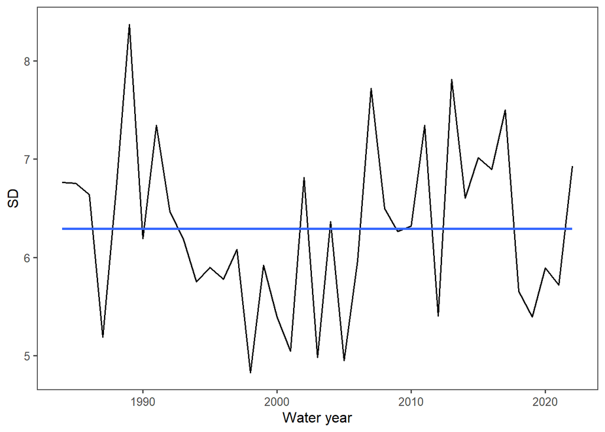

```r
ggplot(CO1932_standard_dev_all_winter, aes(x = waterYear, y = sd_2))+#, color = waterYear)) +
  geom_line(size= 0.7) +
  #geom_line(aes) +
  theme_few() +
  geom_smooth(method = "lm", se=FALSE) +
  ylab('SD') +
  xlab('Water year')
```

**CO1932 Nov-Mar standard deviation for water years 1984-2022**

Mann-Kendall & Sen’s Slope

Winter standard deviations.

```r
CO1932_sd_mk_winter <- mk.test(CO1932_standard_dev_all_winter$sd_2)
print(CO1932_sd_mk_winter)
```

```
##
##  Mann-Kendall trend test
##
## data:  CO1932_standard_dev_all_winter$sd_2
## z = -0.096775, n = 39, p-value = 0.9229
## alternative hypothesis: true S is not equal to 0
## sample estimates:
##             S          varS           tau
##   -9.00000000 6833.66666667   -0.01214575
```

```r
CO1932_sd_sens_winter <- sens.slope(CO1932_standard_dev_all_winter$sd_2)
print(CO1932_sd_sens_winter)
```

```
##
##  Sen's slope
##
## data:  CO1932_standard_dev_all_winter$sd_2
## z = -0.096775, n = 39, p-value = 0.9229
## alternative hypothesis: true z is not equal to 0
## 95 percent confidence interval:
##  -0.02907046  0.02725867
## sample estimates:
##  Sen's slope
## -0.001356466
```

## STEAMBOAT SPRINGS *CO7936*

Detrending Data

```r
#average water year temperature

CO7936_yearly_wy_aver <- COOP_stations_clean %>%
  filter(station == "CO7936") %>%
  group_by(waterYear) %>%
  filter(waterYear >= 1984) %>%
  mutate(aver_ann_temp = mean(avg_T_c))
```

```r
#Average temperature by day for all water years:

CO7936_daily_wy_aver <- CO7936_yearly_wy_aver %>%
  group_by(daymonth) %>%
  mutate(aver_day_temp = mean(aver_ann_temp))

#average mean temperature by day for the period of record:

CO7936_daily_wy_aver <- CO7936_daily_wy_aver %>%
  group_by(daymonth) %>%
  mutate(all_ave_temp = mean(CO7936_daily_wy_aver$aver_day_temp))

#str(CO7936_daily_wy_aver)
```

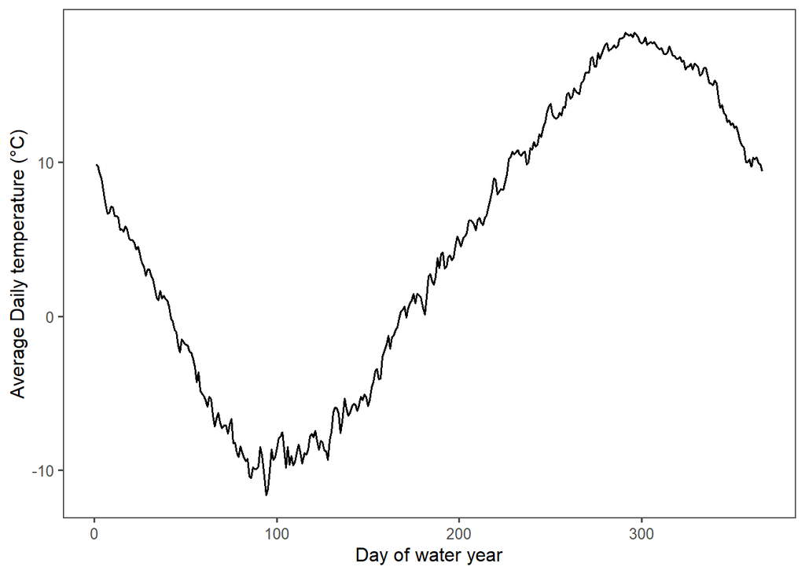

```r
# try to show all years as means.
CO7936_daily_wy_aver2 <- CO7936_daily_wy_aver %>%
  #filter(waterYear == "1987" | waterYear == "2021") %>%
  group_by(waterDay) %>%
  mutate(date_temp = mean(avg_T_c))

CO7936_daily_wy_aver2$date_temp <- signif(CO7936_daily_wy_aver2$date_temp,3) #reduce the sig figs

ggplot(CO7936_daily_wy_aver2, aes(x = waterDay, y = date_temp))+#, color = waterYear)) +
  geom_line(size= 0.7) +
  #geom_line(aes) +
  theme_few() +
  #geom_smooth(method = "lm", se=FALSE) +
  ylab('Average Daily temperature (°C)') +
  xlab('Day of water year')
```

Standard deviation- Determining residuals

```r
CO7936_standard_dev <- CO7936_daily_wy_aver %>%
  group_by(waterYear) %>%
  mutate(residual = (all_ave_temp-aver_ann_temp)+avg_T_c-aver_day_temp) %>%
  mutate(deviation = abs(residual-lag(residual)))

mean(CO7936_standard_dev$residual)
```

```
## [1] 1.536499e-16
```

*The mean of the residuals is close enough to zero*

Calculating standard deviation for the timeseries

```r
CO7936_standard_dev_all <- CO7936_standard_dev %>%
  group_by(waterYear) %>%
  mutate(nmbr = n())

CO7936_standard_dev_all <- CO7936_standard_dev_all %>%
  group_by(waterYear) %>%
  mutate(resid_mean = mean(residual)) %>%
  mutate(sd_1 = residual-resid_mean) %>%
  mutate(sd_2 = (((sum((sd_1)^2))/((nmbr-1))))^(0.5)) %>%
  distinct(sd_2, .keep_all = TRUE) %>%
   select(waterYear, sd_2)

CO7936_standard_dev_all %>%
  kable(.,'html') %>%
  kable_styling() %>%
  scroll_box(width='250px',height='500px')
```

| waterYear | sd_2 |
| --- | --- |
| 1984 | 10.500315 |
| 1985 | 10.331049 |
| 1986 | 9.546770 |
| 1987 | 9.102168 |
| 1988 | 10.958152 |
| 1989 | 10.863926 |
| 1990 | 10.023350 |
| 1991 | 10.418768 |
| 1992 | 9.629944 |
| 1993 | 10.268430 |
| 1994 | 10.466511 |
| 1995 | 9.467851 |
| 1996 | 9.705887 |
| 1997 | 10.248243 |
| 1998 | 10.461905 |
| 1999 | 9.873779 |
| 2000 | 9.769677 |
| 2001 | 11.360586 |
| 2002 | 11.435819 |
| 2003 | 10.114558 |
| 2004 | 9.833531 |
| 2005 | 9.123187 |
| 2006 | 10.735583 |
| 2007 | 10.818504 |
| 2008 | 10.266246 |
| 2009 | 9.317293 |
| 2010 | 10.270779 |
| 2011 | 10.245595 |
| 2012 | 9.836316 |
| 2013 | 11.024487 |
| 2014 | 9.892355 |
| 2015 | 8.911855 |
| 2016 | 10.397083 |
| 2017 | 9.675927 |
| 2018 | 9.395575 |
| 2019 | 10.325819 |
| 2020 | 10.362244 |
| 2021 | 10.332149 |
| 2022 | 10.356318 |

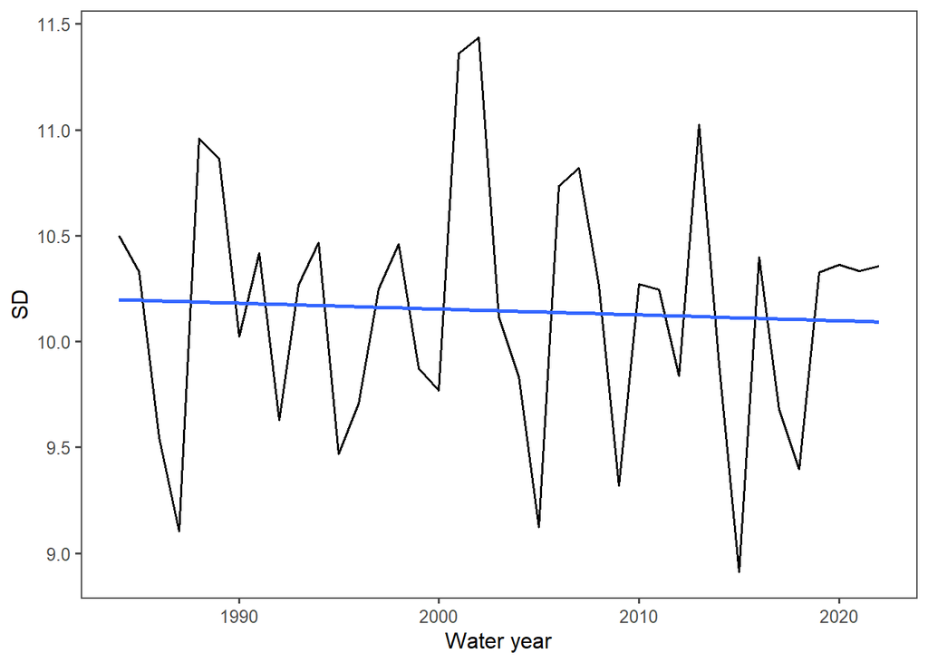

```r
#CALLING THIS something different
CO7936_all_V2 <- ggplot(CO7936_standard_dev_all, aes(x = waterYear, y = sd_2))+
  geom_line(size= 0.7) +
  theme_few() +
  geom_smooth(method = "lm", se=FALSE) +
  ylab('SD') +
  xlab('Water year')


print(CO7936_all_V2)
```

```r
CO7936_sd_mk <- mk.test(CO7936_standard_dev_all$sd_2)
print(CO7936_sd_mk)
```

```
##
##  Mann-Kendall trend test
##
## data:  CO7936_standard_dev_all$sd_2
## z = -0.24194, n = 39, p-value = 0.8088
## alternative hypothesis: true S is not equal to 0
## sample estimates:
##             S          varS           tau
##  -21.00000000 6833.66666667   -0.02834008
```

```r
CO7936_sd_sens <- sens.slope(CO7936_standard_dev_all$sd_2)
print(CO7936_sd_sens)
```

```
##
##  Sen's slope
##
## data:  CO7936_standard_dev_all$sd_2
## z = -0.24194, n = 39, p-value = 0.8088
## alternative hypothesis: true z is not equal to 0
## 95 percent confidence interval:
##  -0.02030299  0.01505127
## sample estimates:
##  Sen's slope
## -0.002523423
```

Summer temperature standard deviation

```r
CO7936_standard_dev_all_summer <- CO7936_standard_dev %>%
  filter(waterDay >= 244 & waterDay <= 335) %>% # this might be better off as daymonth rather than day of water year due to leap year
  group_by(waterYear) %>%
  mutate(nmbr = n())

CO7936_standard_dev_all_summer <- CO7936_standard_dev_all_summer %>%
  group_by(waterYear) %>%
  mutate(resid_mean = mean(residual)) %>%
  mutate(sd_1 = residual-resid_mean) %>%
  mutate(sd_2 = (((sum((sd_1)^2))/((nmbr-1))))^(0.5)) %>%
  distinct(sd_2, .keep_all = TRUE) %>%
   select(waterYear, sd_2)

CO7936_standard_dev_all_summer %>%
  kable(.,'html') %>%
  kable_styling() %>%
  scroll_box(width='250px',height='500px')
```

| waterYear | sd_2 |
| --- | --- |
| 1984 | 3.172889 |
| 1985 | 2.475447 |
| 1986 | 1.756895 |
| 1987 | 2.256401 |
| 1988 | 2.285152 |
| 1989 | 3.360473 |
| 1990 | 2.852068 |
| 1991 | 2.058611 |
| 1992 | 3.096955 |
| 1993 | 3.067035 |
| 1994 | 2.426131 |
| 1995 | 3.305683 |
| 1996 | 2.377386 |
| 1997 | 2.398553 |
| 1998 | 3.580276 |
| 1999 | 2.797057 |
| 2000 | 2.904944 |
| 2001 | 3.460685 |
| 2002 | 3.017018 |
| 2003 | 3.467162 |
| 2004 | 3.122014 |
| 2005 | 3.101184 |
| 2006 | 2.707708 |
| 2007 | 3.544183 |
| 2008 | 3.549712 |
| 2009 | 2.728170 |
| 2010 | 2.607813 |
| 2011 | 2.753046 |
| 2012 | 2.597680 |
| 2013 | 2.552035 |
| 2014 | 3.020503 |
| 2015 | 2.073783 |
| 2016 | 2.293315 |
| 2017 | 2.437804 |
| 2018 | 2.919615 |
| 2019 | 3.330728 |
| 2020 | 2.941152 |
| 2021 | 2.660758 |
| 2022 | 3.097638 |

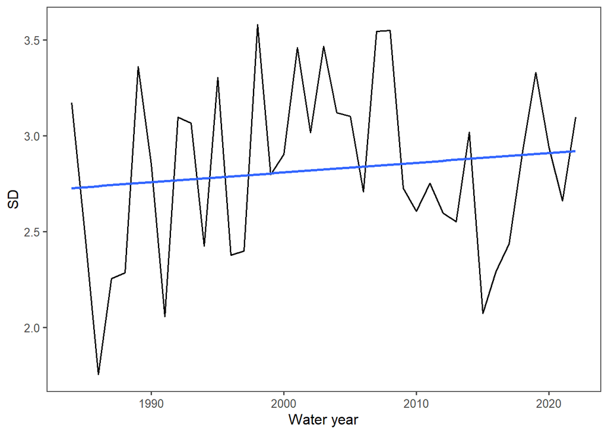

```r
ggplot(CO7936_standard_dev_all_summer, aes(x = waterYear, y = sd_2))+
  geom_line(size= 0.7) +
  theme_few() +
  geom_smooth(method = "lm", se=FALSE) +
  ylab('SD') +
  xlab('Water year')
```

**CO7936 Jun-Aug standard deviation for water years 1984-2022**

Mann-Kendall & Sen’s Slope

Summer standard deviations.

```r
CO7936_sd_mk_summer <- mk.test(CO7936_standard_dev_all_summer$sd_2)
print(CO7936_sd_mk_summer)
```

```
##
##  Mann-Kendall trend test
##
## data:  CO7936_standard_dev_all_summer$sd_2
## z = 0.58065, n = 39, p-value = 0.5615
## alternative hypothesis: true S is not equal to 0
## sample estimates:
##            S         varS          tau
## 4.900000e+01 6.833667e+03 6.612686e-02
```

```r
CO7936_sd_sens_summer <- sens.slope(CO7936_standard_dev_all_summer$sd_2)
print(CO7936_sd_sens_summer)
```

```
##
##  Sen's slope
##
## data:  CO7936_standard_dev_all_summer$sd_2
## z = 0.58065, n = 39, p-value = 0.5615
## alternative hypothesis: true z is not equal to 0
## 95 percent confidence interval:
##  -0.01176159  0.01936204
## sample estimates:
## Sen's slope
## 0.005147536
```

Winter temperature standard deviation

```r
CO7936_standard_dev_all_winter <- CO7936_standard_dev %>%
  filter(waterDay >= 32 & waterDay <= 182) %>% # this might be better off as daymonth rather than day of water year due to leap year
  group_by(waterYear) %>%
  mutate(nmbr = n())

# Nope. This did some weird stuff with twice the observations.
# CO7936_standard_dev_all_winter <- CO7936_standard_dev %>%
#   filter(daymonth >= "01-11" & daymonth <= "31-03") %>%
#   group_by(waterYear) %>%
#   mutate(nmbr = n())


CO7936_standard_dev_all_winter <- CO7936_standard_dev_all_winter %>%
  group_by(waterYear) %>%
  mutate(resid_mean = mean(residual)) %>%
  mutate(sd_1 = residual-resid_mean) %>%
  mutate(sd_2 = (((sum((sd_1)^2))/((nmbr-1))))^(0.5)) %>%
  distinct(sd_2, .keep_all = TRUE) %>%
   select(waterYear, sd_2)

CO7936_standard_dev_all_winter %>%
  kable(.,'html') %>%
  kable_styling() %>%
  scroll_box(width='250px',height='500px')
```

| waterYear | sd_2 |
| --- | --- |
| 1984 | 6.646515 |
| 1985 | 6.458234 |
| 1986 | 6.568330 |
| 1987 | 4.514914 |
| 1988 | 6.587116 |
| 1989 | 7.659194 |
| 1990 | 6.368994 |
| 1991 | 7.092971 |
| 1992 | 6.422494 |
| 1993 | 6.297419 |
| 1994 | 5.731104 |
| 1995 | 5.934439 |
| 1996 | 5.843102 |
| 1997 | 5.830412 |
| 1998 | 5.402242 |
| 1999 | 6.520192 |
| 2000 | 5.513113 |
| 2001 | 5.891148 |
| 2002 | 7.045910 |
| 2003 | 5.302490 |
| 2004 | 6.473448 |
| 2005 | 5.182297 |
| 2006 | 6.100004 |
| 2007 | 7.024869 |
| 2008 | 5.906728 |
| 2009 | 5.640356 |
| 2010 | 5.983123 |
| 2011 | 6.774907 |
| 2012 | 5.146322 |
| 2013 | 7.155593 |
| 2014 | 5.857218 |
| 2015 | 5.946991 |
| 2016 | 5.826514 |
| 2017 | 7.325019 |
| 2018 | 5.197205 |
| 2019 | 5.312714 |
| 2020 | 5.825474 |
| 2021 | 5.355598 |
| 2022 | 6.424842 |

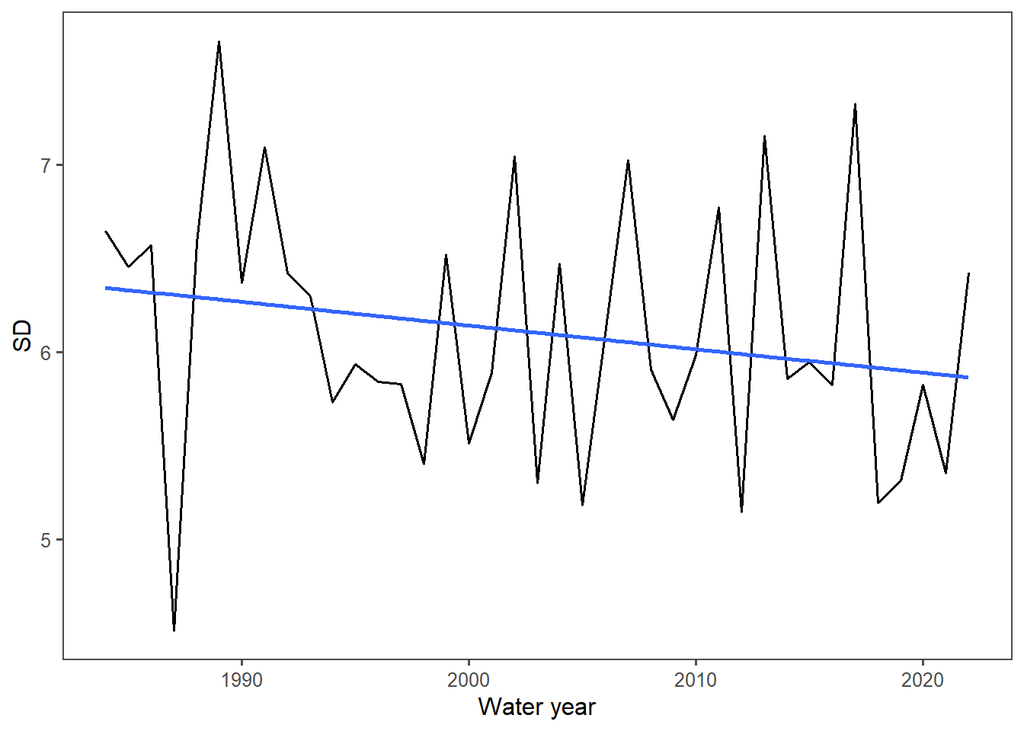

```r
ggplot(CO7936_standard_dev_all_winter, aes(x = waterYear, y = sd_2))+#, color = waterYear)) +
  geom_line(size= 0.7) +
  #geom_line(aes) +
  theme_few() +
  geom_smooth(method = "lm", se=FALSE) +
  ylab('SD') +
  xlab('Water year')
```

**CO7936 Nov-Mar standard deviation for water years 1984-2022**

Mann-Kendall & Sen’s Slope

Winter standard deviations.

```r
CO7936_sd_mk_winter <- mk.test(CO7936_standard_dev_all_winter$sd_2)
print(CO7936_sd_mk_winter)
```

```
##
##  Mann-Kendall trend test
##
## data:  CO7936_standard_dev_all_winter$sd_2
## z = -1.7661, n = 39, p-value = 0.07737
## alternative hypothesis: true S is not equal to 0
## sample estimates:
##            S         varS          tau
## -147.0000000 6833.6666667   -0.1983806
```

```r
CO7936_sd_sens_winter <- sens.slope(CO7936_standard_dev_all_winter$sd_2)
print(CO7936_sd_sens_winter)
```

```
##
##  Sen's slope
##
## data:  CO7936_standard_dev_all_winter$sd_2
## z = -1.7661, n = 39, p-value = 0.07737
## alternative hypothesis: true z is not equal to 0
## 95 percent confidence interval:
##  -0.036423474  0.002225703
## sample estimates:
## Sen's slope
## -0.01995043
```

# Southern Stations

## HERMIT 7 ESE *CO3951*

Detrending Data

```r
#average water year temperature

CO3951_yearly_wy_aver <- COOP_stations_clean %>%
  filter(station == "CO3951") %>%
  group_by(waterYear) %>%
  filter(waterYear >= 1984) %>%
  mutate(aver_ann_temp = mean(avg_T_c))
```

```r
#Average temperature by day for all water years:

CO3951_daily_wy_aver <- CO3951_yearly_wy_aver %>%
  group_by(daymonth) %>%
  mutate(aver_day_temp = mean(aver_ann_temp))

#average mean temperature by day for the period of record:

CO3951_daily_wy_aver <- CO3951_daily_wy_aver %>%
  group_by(daymonth) %>%
  mutate(all_ave_temp = mean(CO3951_daily_wy_aver$aver_day_temp))

#str(CO3951_daily_wy_aver)
```

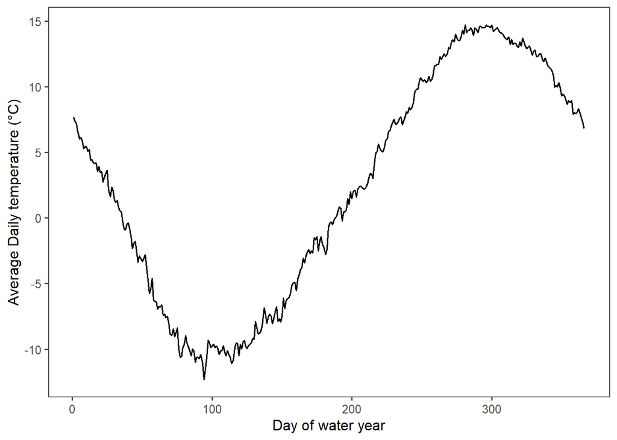

```r
# try to show all years as means.
CO3951_daily_wy_aver2 <- CO3951_daily_wy_aver %>%
  #filter(waterYear == "1987" | waterYear == "2021") %>%
  group_by(waterDay) %>%
  mutate(date_temp = mean(avg_T_c))

CO3951_daily_wy_aver2$date_temp <- signif(CO3951_daily_wy_aver2$date_temp,3) #reduce the sig figs

ggplot(CO3951_daily_wy_aver2, aes(x = waterDay, y = date_temp))+#, color = waterYear)) +
  geom_line(size= 0.7) +
  #geom_line(aes) +
  theme_few() +
  #geom_smooth(method = "lm", se=FALSE) +
  ylab('Average Daily temperature (°C)') +
  xlab('Day of water year')
```

Standard deviation- Determining residuals

```r
CO3951_standard_dev <- CO3951_daily_wy_aver %>%
  group_by(waterYear) %>%
  mutate(residual = (all_ave_temp-aver_ann_temp)+avg_T_c-aver_day_temp) %>%
  mutate(deviation = abs(residual-lag(residual)))

mean(CO3951_standard_dev$residual)
```

```
## [1] -1.486535e-16
```

*The mean of the residuals is close enough to zero*

Calculating standard deviation for the timeseries

```r
CO3951_standard_dev_all <- CO3951_standard_dev %>%
  group_by(waterYear) %>%
  mutate(nmbr = n())

CO3951_standard_dev_all <- CO3951_standard_dev_all %>%
  group_by(waterYear) %>%
  mutate(resid_mean = mean(residual)) %>%
  mutate(sd_1 = residual-resid_mean) %>%
  mutate(sd_2 = (((sum((sd_1)^2))/((nmbr-1))))^(0.5)) %>%
  distinct(sd_2, .keep_all = TRUE) %>%
   select(waterYear, sd_2)

CO3951_standard_dev_all %>%
  kable(.,'html') %>%
  kable_styling() %>%
  scroll_box(width='250px',height='500px')
```

| waterYear | sd_2 |
| --- | --- |
| 1984 | 10.415412 |
| 1985 | 10.277513 |
| 1986 | 9.542602 |
| 1987 | 10.002142 |
| 1988 | 9.602689 |
| 1989 | 10.798841 |
| 1990 | 8.602389 |
| 1991 | 11.152040 |
| 1992 | 10.324649 |
| 1993 | 10.969684 |
| 1994 | 9.740607 |
| 1995 | 8.794524 |
| 1996 | 8.129266 |
| 1997 | 8.939283 |
| 1998 | 9.219493 |
| 1999 | 7.567821 |
| 2000 | 8.463930 |
| 2001 | 9.600737 |
| 2002 | 9.817103 |
| 2003 | 9.034250 |
| 2004 | 8.640154 |
| 2005 | 8.893249 |
| 2006 | 8.527566 |
| 2007 | 9.230474 |
| 2008 | 11.455350 |
| 2009 | 8.446360 |
| 2010 | 10.018255 |
| 2011 | 9.492496 |
| 2012 | 9.637339 |
| 2013 | 10.237010 |
| 2014 | 8.952825 |
| 2015 | 8.294359 |
| 2016 | 9.539250 |
| 2017 | 7.706123 |
| 2018 | 7.518636 |
| 2019 | 8.904952 |
| 2020 | 9.340397 |
| 2021 | 8.995937 |
| 2022 | 8.327062 |

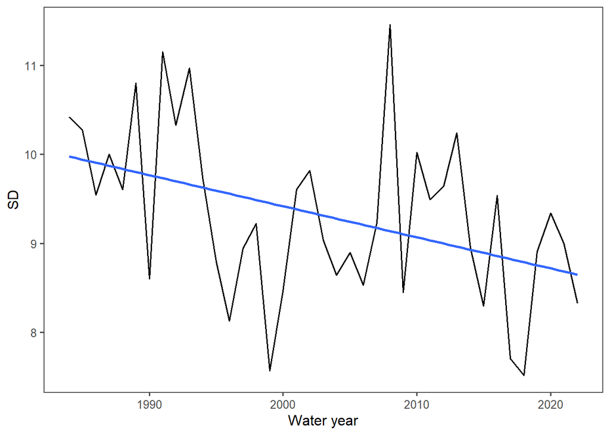

```r
ggplot(CO3951_standard_dev_all, aes(x = waterYear, y = sd_2))+
  geom_line(size= 0.7) +
  theme_few() +
  geom_smooth(method = "lm", se=FALSE) +
  ylab('SD') +
  xlab('Water year')
```

```r
CO3951_sd_mk <- mk.test(CO3951_standard_dev_all$sd_2)
print(CO3951_sd_mk)
```

```
##
##  Mann-Kendall trend test
##
## data:  CO3951_standard_dev_all$sd_2
## z = -2.5403, n = 39, p-value = 0.01107
## alternative hypothesis: true S is not equal to 0
## sample estimates:
##            S         varS          tau
## -211.0000000 6833.6666667   -0.2847503
```

```r
CO3951_sd_sens <- sens.slope(CO3951_standard_dev_all$sd_2)
print(CO3951_sd_sens)
```

```
##
##  Sen's slope
##
## data:  CO3951_standard_dev_all$sd_2
## z = -2.5403, n = 39, p-value = 0.01107
## alternative hypothesis: true z is not equal to 0
## 95 percent confidence interval:
##  -0.063129656 -0.009152621
## sample estimates:
## Sen's slope
## -0.03704864
```

Summer temperature standard deviation

```r
CO3951_standard_dev_all_summer <- CO3951_standard_dev %>%
  filter(waterDay >= 244 & waterDay <= 335) %>% # this might be better off as daymonth rather than day of water year due to leap year
  group_by(waterYear) %>%
  mutate(nmbr = n())

CO3951_standard_dev_all_summer <- CO3951_standard_dev_all_summer %>%
  group_by(waterYear) %>%
  mutate(resid_mean = mean(residual)) %>%
  mutate(sd_1 = residual-resid_mean) %>%
  mutate(sd_2 = (((sum((sd_1)^2))/((nmbr-1))))^(0.5)) %>%
  distinct(sd_2, .keep_all = TRUE) %>%
   select(waterYear, sd_2)

CO3951_standard_dev_all_summer %>%
  kable(.,'html') %>%
  kable_styling() %>%
  scroll_box(width='250px',height='500px')
```

| waterYear | sd_2 |
| --- | --- |
| 1984 | 2.538404 |
| 1985 | 2.147649 |
| 1986 | 1.952084 |
| 1987 | 2.140107 |
| 1988 | 2.385361 |
| 1989 | 3.079231 |
| 1990 | 2.265816 |
| 1991 | 2.385897 |
| 1992 | 2.454909 |
| 1993 | 2.091957 |
| 1994 | 1.875514 |
| 1995 | 3.130271 |
| 1996 | 2.415712 |
| 1997 | 2.296753 |
| 1998 | 2.951996 |
| 1999 | 2.516925 |
| 2000 | 1.783939 |
| 2001 | 2.588537 |
| 2002 | 2.179619 |
| 2003 | 3.039591 |
| 2004 | 2.921908 |
| 2005 | 3.151072 |
| 2006 | 2.379912 |
| 2007 | 2.539680 |
| 2008 | 2.878280 |
| 2009 | 3.300945 |
| 2010 | 2.449897 |
| 2011 | 2.580680 |
| 2012 | 2.050128 |
| 2013 | 2.336105 |
| 2014 | 2.498279 |
| 2015 | 2.588692 |
| 2016 | 2.540992 |
| 2017 | 1.857542 |
| 2018 | 1.817750 |
| 2019 | 2.241689 |
| 2020 | 1.921353 |
| 2021 | 1.939761 |
| 2022 | 1.837502 |

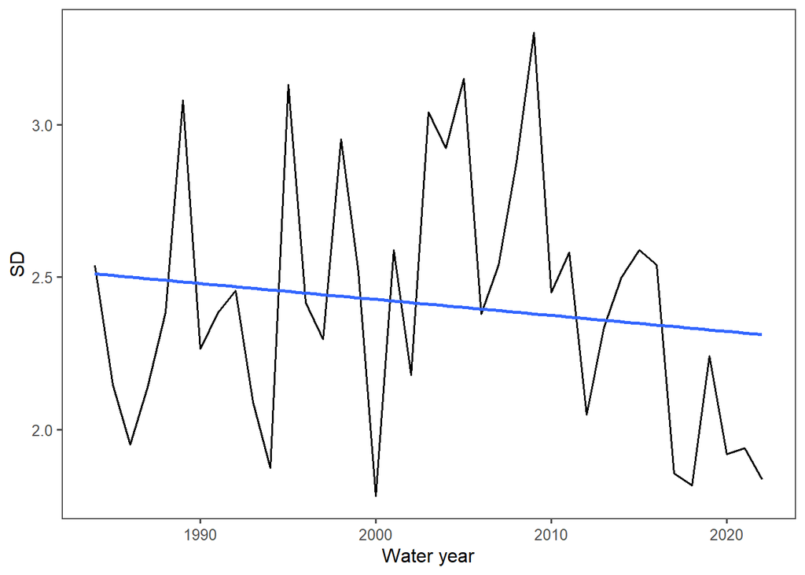

```r
ggplot(CO3951_standard_dev_all_summer, aes(x = waterYear, y = sd_2))+
  geom_line(size= 0.7) +
  theme_few() +
  geom_smooth(method = "lm", se=FALSE) +
  ylab('SD') +
  xlab('Water year')
```

**CO3951 Jun-Aug standard deviation for water years 1984-2022**

Mann-Kendall & Sen’s Slope

Summer standard deviations.

```r
CO3951_sd_mk_summer <- mk.test(CO3951_standard_dev_all_summer$sd_2)
print(CO3951_sd_mk_summer)
```

```
##
##  Mann-Kendall trend test
##
## data:  CO3951_standard_dev_all_summer$sd_2
## z = -0.67742, n = 39, p-value = 0.4981
## alternative hypothesis: true S is not equal to 0
## sample estimates:
##             S          varS           tau
##  -57.00000000 6833.66666667   -0.07692308
```

```r
CO3951_sd_sens_summer <- sens.slope(CO3951_standard_dev_all_summer$sd_2)
print(CO3951_sd_sens_summer)
```

```
##
##  Sen's slope
##
## data:  CO3951_standard_dev_all_summer$sd_2
## z = -0.67742, n = 39, p-value = 0.4981
## alternative hypothesis: true z is not equal to 0
## 95 percent confidence interval:
##  -0.018200664  0.007538382
## sample estimates:
##  Sen's slope
## -0.004634582
```

Winter temperature standard deviation

```r
CO3951_standard_dev_all_winter <- CO3951_standard_dev %>%
  filter(waterDay >= 32 & waterDay <= 182) %>% # this might be better off as daymonth rather than day of water year due to leap year
  group_by(waterYear) %>%
  mutate(nmbr = n())

# Nope. This did some weird stuff with twice the observations.
# CO3951_standard_dev_all_winter <- CO3951_standard_dev %>%
#   filter(daymonth >= "01-11" & daymonth <= "31-03") %>%
#   group_by(waterYear) %>%
#   mutate(nmbr = n())


CO3951_standard_dev_all_winter <- CO3951_standard_dev_all_winter %>%
  group_by(waterYear) %>%
  mutate(resid_mean = mean(residual)) %>%
  mutate(sd_1 = residual-resid_mean) %>%
  mutate(sd_2 = (((sum((sd_1)^2))/((nmbr-1))))^(0.5)) %>%
  distinct(sd_2, .keep_all = TRUE) %>%
   select(waterYear, sd_2)

CO3951_standard_dev_all_winter %>%
  kable(.,'html') %>%
  kable_styling() %>%
  scroll_box(width='250px',height='500px')
```

| waterYear | sd_2 |
| --- | --- |
| 1984 | 5.967498 |
| 1985 | 6.536370 |
| 1986 | 5.105752 |
| 1987 | 4.663605 |
| 1988 | 5.470687 |
| 1989 | 7.132174 |
| 1990 | 5.469040 |
| 1991 | 5.619718 |
| 1992 | 5.388899 |
| 1993 | 4.067827 |
| 1994 | 5.674534 |
| 1995 | 5.172757 |
| 1996 | 5.241253 |
| 1997 | 4.668863 |
| 1998 | 5.126438 |
| 1999 | 3.945550 |
| 2000 | 4.904276 |
| 2001 | 4.578327 |
| 2002 | 6.002350 |
| 2003 | 4.653933 |
| 2004 | 6.098215 |
| 2005 | 4.823270 |
| 2006 | 5.185307 |
| 2007 | 6.222375 |
| 2008 | 6.918677 |
| 2009 | 5.365503 |
| 2010 | 5.785504 |
| 2011 | 6.284954 |
| 2012 | 5.283302 |
| 2013 | 6.712728 |
| 2014 | 5.121854 |
| 2015 | 5.531587 |
| 2016 | 6.076645 |
| 2017 | 5.967407 |
| 2018 | 4.496672 |
| 2019 | 4.774990 |
| 2020 | 5.511251 |
| 2021 | 4.821601 |
| 2022 | 4.714724 |

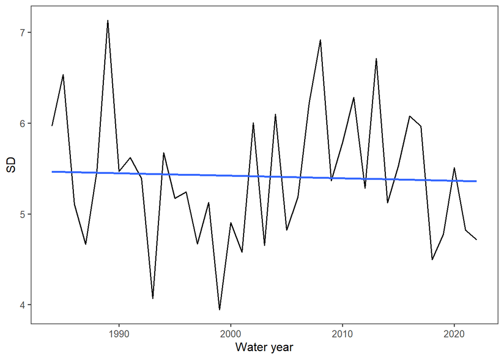

```r
ggplot(CO3951_standard_dev_all_winter, aes(x = waterYear, y = sd_2))+#, color = waterYear)) +
  geom_line(size= 0.7) +
  #geom_line(aes) +
  theme_few() +
  geom_smooth(method = "lm", se=FALSE) +
  ylab('SD') +
  xlab('Water year')
```

**CO3951 Nov-Mar standard deviation for water years 1984-2022**

Mann-Kendall & Sen’s Slope

Winter standard deviations.

```r
CO3951_sd_mk_winter <- mk.test(CO3951_standard_dev_all_winter$sd_2)
print(CO3951_sd_mk_winter)
```

```
##
##  Mann-Kendall trend test
##
## data:  CO3951_standard_dev_all_winter$sd_2
## z = -0.31452, n = 39, p-value = 0.7531
## alternative hypothesis: true S is not equal to 0
## sample estimates:
##             S          varS           tau
##  -27.00000000 6833.66666667   -0.03643725
```

```r
CO3951_sd_sens_winter <- sens.slope(CO3951_standard_dev_all_winter$sd_2)
print(CO3951_sd_sens_winter)
```

```
##
##  Sen's slope
##
## data:  CO3951_standard_dev_all_winter$sd_2
## z = -0.31452, n = 39, p-value = 0.7531
## alternative hypothesis: true z is not equal to 0
## 95 percent confidence interval:
##  -0.02728328  0.02164135
## sample estimates:
##  Sen's slope
## -0.003936932
```

## PAGOSA SPRINGS *CO6258*

Detrending Data

```r
#average water year temperature

CO6258_yearly_wy_aver <- COOP_stations_clean %>%
  filter(station == "CO6258") %>%
  group_by(waterYear) %>%
  filter(waterYear >= 1984) %>%
  mutate(aver_ann_temp = mean(avg_T_c))
```

```r
#Average temperature by day for all water years:

CO6258_daily_wy_aver <- CO6258_yearly_wy_aver %>%
  group_by(daymonth) %>%
  mutate(aver_day_temp = mean(aver_ann_temp))

#average mean temperature by day for the period of record:

CO6258_daily_wy_aver <- CO6258_daily_wy_aver %>%
  group_by(daymonth) %>%
  mutate(all_ave_temp = mean(CO6258_daily_wy_aver$aver_day_temp))

#str(CO6258_daily_wy_aver)
```

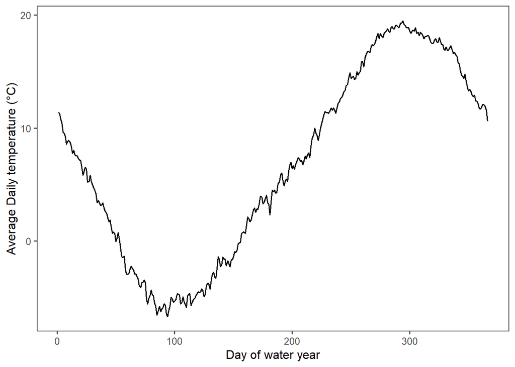

```r
# try to show all years as means.
CO6258_daily_wy_aver2 <- CO6258_daily_wy_aver %>%
  #filter(waterYear == "1987" | waterYear == "2021") %>%
  group_by(waterDay) %>%
  mutate(date_temp = mean(avg_T_c))

CO6258_daily_wy_aver2$date_temp <- signif(CO6258_daily_wy_aver2$date_temp,3) #reduce the sig figs

ggplot(CO6258_daily_wy_aver2, aes(x = waterDay, y = date_temp))+#, color = waterYear)) +
  geom_line(size= 0.7) +
  #geom_line(aes) +
  theme_few() +
  #geom_smooth(method = "lm", se=FALSE) +
  ylab('Average Daily temperature (°C)') +
  xlab('Day of water year')
```

Standard deviation- Determining residuals

```r
CO6258_standard_dev <- CO6258_daily_wy_aver %>%
  group_by(waterYear) %>%
  mutate(residual = (all_ave_temp-aver_ann_temp)+avg_T_c-aver_day_temp) %>%
  mutate(deviation = abs(residual-lag(residual)))

mean(CO6258_standard_dev$residual)
```

```
## [1] 5.67087e-17
```

*The mean of the residuals is close enough to zero*

Calculating standard deviation for the timeseries

```r
CO6258_standard_dev_all <- CO6258_standard_dev %>%
  group_by(waterYear) %>%
  mutate(nmbr = n())

CO6258_standard_dev_all <- CO6258_standard_dev_all %>%
  group_by(waterYear) %>%
  mutate(resid_mean = mean(residual)) %>%
  mutate(sd_1 = residual-resid_mean) %>%
  mutate(sd_2 = (((sum((sd_1)^2))/((nmbr-1))))^(0.5)) %>%
  distinct(sd_2, .keep_all = TRUE) %>%
   select(waterYear, sd_2)

CO6258_standard_dev_all %>%
  kable(.,'html') %>%
  kable_styling() %>%
  scroll_box(width='250px',height='500px')
```

| waterYear | sd_2 |
| --- | --- |
| 1984 | 9.621109 |
| 1985 | 8.850435 |
| 1986 | 8.127376 |
| 1987 | 8.136447 |
| 1988 | 9.282846 |
| 1989 | 9.278439 |
| 1990 | 9.333070 |
| 1991 | 9.521059 |
| 1992 | 8.867230 |
| 1993 | 8.725111 |
| 1994 | 9.210796 |
| 1995 | 7.594386 |
| 1996 | 8.275978 |
| 1997 | 8.477917 |
| 1998 | 9.298074 |
| 1999 | 7.505010 |
| 2000 | 8.509675 |
| 2001 | 9.120501 |
| 2002 | 9.461970 |
| 2003 | 8.578818 |
| 2004 | 8.682985 |
| 2005 | 8.265464 |
| 2006 | 8.664025 |
| 2007 | 9.317649 |
| 2008 | 9.654025 |
| 2009 | 8.448231 |
| 2010 | 9.552162 |
| 2011 | 9.278457 |
| 2012 | 9.096617 |
| 2013 | 10.108497 |
| 2014 | 8.982317 |
| 2015 | 8.346630 |
| 2016 | 9.204208 |
| 2017 | 8.491701 |
| 2018 | 8.689142 |
| 2019 | 9.455367 |
| 2020 | 6.342730 |

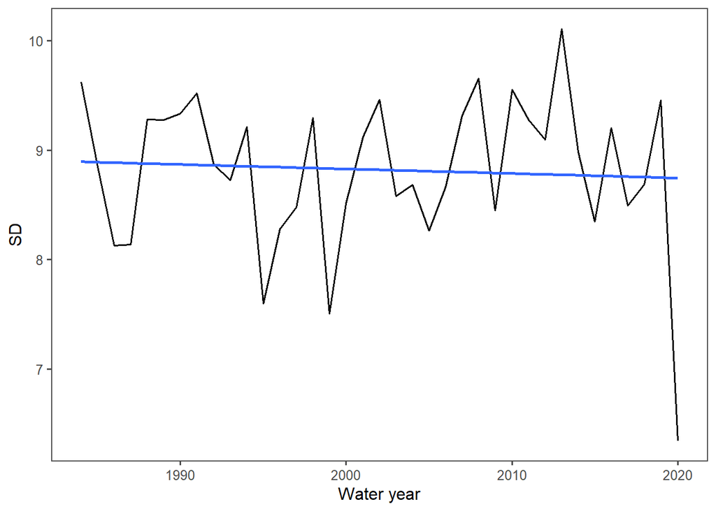

```r
ggplot(CO6258_standard_dev_all, aes(x = waterYear, y = sd_2))+
  geom_line(size= 0.7) +
  theme_few() +
  geom_smooth(method = "lm", se=FALSE) +
  ylab('SD') +
  xlab('Water year')
```

```r
CO6258_sd_mk <- mk.test(CO6258_standard_dev_all$sd_2)
print(CO6258_sd_mk)
```

```
##
##  Mann-Kendall trend test
##
## data:  CO6258_standard_dev_all$sd_2
## z = 0, n = 37, p-value = 1
## alternative hypothesis: true S is not equal to 0
## sample estimates:
##    S varS  tau
##    0 5846    0
```

```r
CO6258_sd_sens <- sens.slope(CO6258_standard_dev_all$sd_2)
print(CO6258_sd_sens)
```

```
##
##  Sen's slope
##
## data:  CO6258_standard_dev_all$sd_2
## z = 0, n = 37, p-value = 1
## alternative hypothesis: true z is not equal to 0
## 95 percent confidence interval:
##  -0.01841155  0.02133537
## sample estimates:
##   Sen's slope
## -9.500005e-05
```

Summer temperature standard deviation

```r
CO6258_standard_dev_all_summer <- CO6258_standard_dev %>%
  filter(waterDay >= 244 & waterDay <= 335) %>% # this might be better off as daymonth rather than day of water year due to leap year
  group_by(waterYear) %>%
  mutate(nmbr = n())

CO6258_standard_dev_all_summer <- CO6258_standard_dev_all_summer %>%
  group_by(waterYear) %>%
  mutate(resid_mean = mean(residual)) %>%
  mutate(sd_1 = residual-resid_mean) %>%
  mutate(sd_2 = (((sum((sd_1)^2))/((nmbr-1))))^(0.5)) %>%
  distinct(sd_2, .keep_all = TRUE) %>%
   select(waterYear, sd_2)

CO6258_standard_dev_all_summer %>%
  kable(.,'html') %>%
  kable_styling() %>%
  scroll_box(width='250px',height='500px')
```

| waterYear | sd_2 |
| --- | --- |
| 1984 | 2.892384 |
| 1985 | 2.715438 |
| 1986 | 2.591211 |
| 1987 | 2.509227 |
| 1988 | 2.800926 |
| 1989 | 2.890526 |
| 1990 | 2.720643 |
| 1991 | 2.759886 |
| 1992 | 2.859440 |
| 1993 | 2.634856 |
| 1994 | 1.609511 |
| 1995 | 3.033733 |
| 1996 | 2.114957 |
| 1997 | 2.291399 |
| 1998 | 3.466096 |
| 1999 | 2.339192 |
| 2000 | 1.556421 |
| 2001 | 2.215516 |
| 2002 | 1.798817 |
| 2003 | 2.795610 |
| 2004 | 2.271127 |
| 2005 | 2.848113 |
| 2006 | 1.810277 |
| 2007 | 2.411843 |
| 2008 | 2.442893 |
| 2009 | 2.719712 |
| 2010 | 2.249149 |
| 2011 | 2.347447 |
| 2012 | 1.751127 |
| 2013 | 2.083785 |
| 2014 | 2.157003 |
| 2015 | 2.092536 |
| 2016 | 2.370134 |
| 2017 | 1.874753 |
| 2018 | 1.971475 |
| 2019 | 2.536731 |

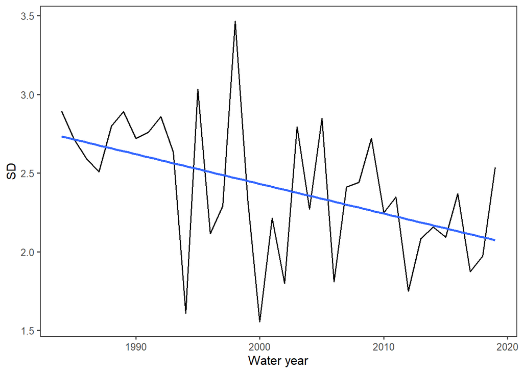

```r
ggplot(CO6258_standard_dev_all_summer, aes(x = waterYear, y = sd_2))+
  geom_line(size= 0.7) +
  theme_few() +
  geom_smooth(method = "lm", se=FALSE) +
  ylab('SD') +
  xlab('Water year')
```

Mann-Kendall & Sen’s Slope

Summer standard deviations.

```r
CO6258_sd_mk_summer <- mk.test(CO6258_standard_dev_all_summer$sd_2)
print(CO6258_sd_mk_summer)
```

```
##
##  Mann-Kendall trend test
##
## data:  CO6258_standard_dev_all_summer$sd_2
## z = -2.7923, n = 36, p-value = 0.005234
## alternative hypothesis: true S is not equal to 0
## sample estimates:
##            S         varS          tau
## -206.0000000 5390.0000000   -0.3269841
```

```r
CO6258_sd_sens_summer <- sens.slope(CO6258_standard_dev_all_summer$sd_2)
print(CO6258_sd_sens_summer)
```

```
##
##  Sen's slope
##
## data:  CO6258_standard_dev_all_summer$sd_2
## z = -2.7923, n = 36, p-value = 0.005234
## alternative hypothesis: true z is not equal to 0
## 95 percent confidence interval:
##  -0.03069192 -0.00690688
## sample estimates:
## Sen's slope
## -0.01936016
```

Winter temperature standard deviation

```r
CO6258_standard_dev_all_winter <- CO6258_standard_dev %>%
  filter(waterDay >= 32 & waterDay <= 182) %>% # this might be better off as daymonth rather than day of water year due to leap year
  group_by(waterYear) %>%
  mutate(nmbr = n())

# Nope. This did some weird stuff with twice the observations.
# CO6258_standard_dev_all_winter <- CO6258_standard_dev %>%
#   filter(daymonth >= "01-11" & daymonth <= "31-03") %>%
#   group_by(waterYear) %>%
#   mutate(nmbr = n())


CO6258_standard_dev_all_winter <- CO6258_standard_dev_all_winter %>%
  group_by(waterYear) %>%
  mutate(resid_mean = mean(residual)) %>%
  mutate(sd_1 = residual-resid_mean) %>%
  mutate(sd_2 = (((sum((sd_1)^2))/((nmbr-1))))^(0.5)) %>%
  distinct(sd_2, .keep_all = TRUE) %>%
   select(waterYear, sd_2)

CO6258_standard_dev_all_winter %>%
  kable(.,'html') %>%
  kable_styling() %>%
  scroll_box(width='250px',height='500px')
```

| waterYear | sd_2 |
| --- | --- |
| 1984 | 5.539382 |
| 1985 | 5.221322 |
| 1986 | 5.151056 |
| 1987 | 4.006869 |
| 1988 | 5.463126 |
| 1989 | 6.081710 |
| 1990 | 5.501666 |
| 1991 | 5.959856 |
| 1992 | 4.854584 |
| 1993 | 4.839559 |
| 1994 | 4.459638 |
| 1995 | 4.086126 |
| 1996 | 4.602684 |
| 1997 | 4.824240 |
| 1998 | 4.287481 |
| 1999 | 3.999260 |
| 2000 | 4.513163 |
| 2001 | 3.948779 |
| 2002 | 5.199542 |
| 2003 | 3.698090 |
| 2004 | 5.469668 |
| 2005 | 3.678975 |
| 2006 | 4.423239 |
| 2007 | 5.636067 |
| 2008 | 6.071441 |
| 2009 | 4.686136 |
| 2010 | 4.810118 |
| 2011 | 5.553928 |
| 2012 | 4.251732 |
| 2013 | 6.212543 |
| 2014 | 4.618260 |
| 2015 | 4.988689 |
| 2016 | 5.296415 |
| 2017 | 5.513993 |
| 2018 | 4.031030 |
| 2019 | 4.772180 |
| 2020 | 4.874283 |

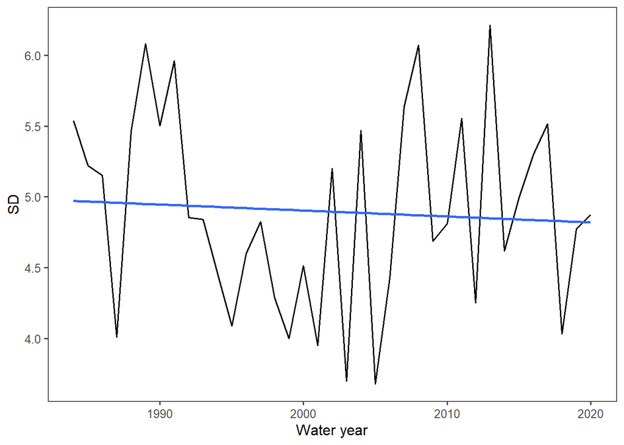

```r
ggplot(CO6258_standard_dev_all_winter, aes(x = waterYear, y = sd_2))+#, color = waterYear)) +
  geom_line(size= 0.7) +
  #geom_line(aes) +
  theme_few() +
  geom_smooth(method = "lm", se=FALSE) +
  ylab('SD') +
  xlab('Water year')
```

Mann-Kendall & Sen’s Slope

Winter standard deviations.

```r
CO6258_sd_mk_winter <- mk.test(CO6258_standard_dev_all_winter$sd_2)
print(CO6258_sd_mk_winter)
```

```
##
##  Mann-Kendall trend test
##
## data:  CO6258_standard_dev_all_winter$sd_2
## z = -0.48392, n = 37, p-value = 0.6284
## alternative hypothesis: true S is not equal to 0
## sample estimates:
##             S          varS           tau
##  -38.00000000 5846.00000000   -0.05705706
```

```r
CO6258_sd_sens_winter <- sens.slope(CO6258_standard_dev_all_winter$sd_2)
print(CO6258_sd_sens_winter)
```

```
##
##  Sen's slope
##
## data:  CO6258_standard_dev_all_winter$sd_2
## z = -0.48392, n = 37, p-value = 0.6284
## alternative hypothesis: true z is not equal to 0
## 95 percent confidence interval:
##  -0.03081031  0.01926972
## sample estimates:
##  Sen's slope
## -0.005776429
```

## SILVERTON *CO7656*

Detrending Data

```r
#average water year temperature

CO7656_yearly_wy_aver <- COOP_stations_clean %>%
  filter(station == "CO7656") %>%
  group_by(waterYear) %>%
  filter(waterYear >= 1984) %>%
  mutate(aver_ann_temp = mean(avg_T_c))

CO7656_temp_xts <- xts(CO7656_yearly_wy_aver$avg_T_c, order.by = CO7656_yearly_wy_aver$Date)

dygraph(CO7656_temp_xts) %>%
  dyAxis("y", label = "Daily temperature (°C)")
```

[interactive chart not shown]

```r
#Average temperature by day for all water years:

CO7656_daily_wy_aver <- CO7656_yearly_wy_aver %>%
  group_by(daymonth) %>%
  mutate(aver_day_temp = mean(aver_ann_temp))

#average mean temperature by day for the period of record:

CO7656_daily_wy_aver <- CO7656_daily_wy_aver %>%
  group_by(daymonth) %>%
  mutate(all_ave_temp = mean(CO7656_daily_wy_aver$aver_day_temp))

#str(CO7656_daily_wy_aver)
```

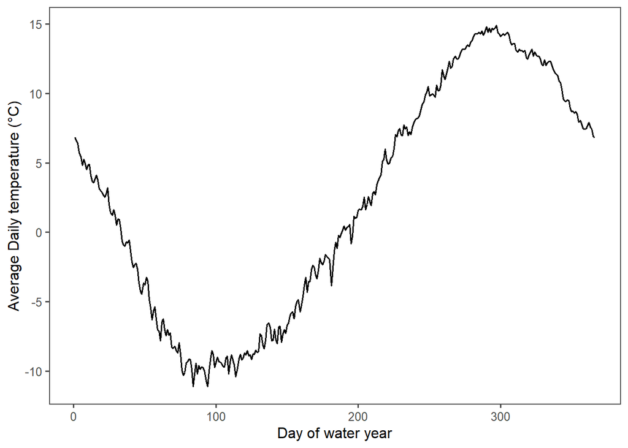

```r
# try to show all years as means.
CO7656_daily_wy_aver2 <- CO7656_daily_wy_aver %>%
  #filter(waterYear == "1987" | waterYear == "2021") %>%
  group_by(waterDay) %>%
  mutate(date_temp = mean(avg_T_c))

CO7656_daily_wy_aver2$date_temp <- signif(CO7656_daily_wy_aver2$date_temp,3) #reduce the sig figs

ggplot(CO7656_daily_wy_aver2, aes(x = waterDay, y = date_temp))+#, color = waterYear)) +
  geom_line(size= 0.7) +
  #geom_line(aes) +
  theme_few() +
  #geom_smooth(method = "lm", se=FALSE) +
  ylab('Average Daily temperature (°C)') +
  xlab('Day of water year')
```

Standard deviation- Determining residuals

```r
CO7656_standard_dev <- CO7656_daily_wy_aver %>%
  group_by(waterYear) %>%
  mutate(residual = (all_ave_temp-aver_ann_temp)+avg_T_c-aver_day_temp) %>%
  mutate(deviation = abs(residual-lag(residual)))

mean(CO7656_standard_dev$residual)
```

```
## [1] -3.691746e-17
```

*The mean of the residuals is close enough to zero*

Calculating standard deviation for the timeseries

```r
CO7656_standard_dev_all <- CO7656_standard_dev %>%
  group_by(waterYear) %>%
  mutate(nmbr = n())

CO7656_standard_dev_all <- CO7656_standard_dev_all %>%
  group_by(waterYear) %>%
  mutate(resid_mean = mean(residual)) %>%
  mutate(sd_1 = residual-resid_mean) %>%
  mutate(sd_2 = (((sum((sd_1)^2))/((nmbr-1))))^(0.5)) %>%
  distinct(sd_2, .keep_all = TRUE) %>%
   select(waterYear, sd_2)

CO7656_standard_dev_all %>%
  kable(.,'html') %>%
  kable_styling() %>%
  scroll_box(width='250px',height='500px')
```

| waterYear | sd_2 |
| --- | --- |
| 1984 | 9.800356 |
| 1985 | 9.286243 |
| 1986 | 8.190448 |
| 1987 | 8.552234 |
| 1988 | 9.163062 |
| 1989 | 9.244891 |
| 1990 | 8.705592 |
| 1991 | 9.568655 |
| 1992 | 8.473835 |
| 1993 | 8.837258 |
| 1994 | 9.549772 |
| 1995 | 8.757576 |
| 1996 | 8.542260 |
| 1997 | 9.124829 |
| 1998 | 9.393025 |
| 1999 | 7.785032 |
| 2000 | 8.493772 |
| 2001 | 9.124296 |
| 2002 | 9.260411 |
| 2003 | 8.916683 |
| 2004 | 8.666508 |
| 2005 | 8.031985 |
| 2006 | 8.595742 |
| 2007 | 9.260942 |
| 2008 | 9.602807 |
| 2009 | 8.642532 |
| 2010 | 9.778187 |
| 2011 | 9.699779 |
| 2012 | 10.200554 |
| 2013 | 10.042336 |
| 2014 | 9.013978 |
| 2015 | 8.191825 |
| 2016 | 9.335647 |
| 2017 | 8.888276 |
| 2018 | 9.205000 |
| 2019 | 11.507607 |
| 2020 | 9.458099 |
| 2021 | 9.407391 |
| 2022 | 9.248475 |

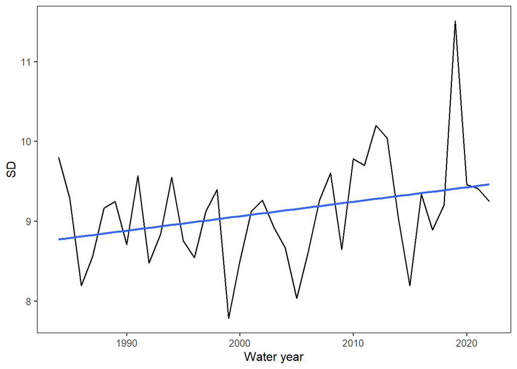

```r
ggplot(CO7656_standard_dev_all, aes(x = waterYear, y = sd_2))+
  geom_line(size= 0.7) +
  theme_few() +
  geom_smooth(method = "lm", se=FALSE) +
  ylab('SD') +
  xlab('Water year')
```

```r
CO7656_sd_mk <- mk.test(CO7656_standard_dev_all$sd_2)
print(CO7656_sd_mk)
```

```
##
##  Mann-Kendall trend test
##
## data:  CO7656_standard_dev_all$sd_2
## z = 1.6452, n = 39, p-value = 0.09993
## alternative hypothesis: true S is not equal to 0
## sample estimates:
##            S         varS          tau
##  137.0000000 6833.6666667    0.1848853
```

```r
CO7656_sd_sens <- sens.slope(CO7656_standard_dev_all$sd_2)
print(CO7656_sd_sens)
```

```
##
##  Sen's slope
##
## data:  CO7656_standard_dev_all$sd_2
## z = 1.6452, n = 39, p-value = 0.09993
## alternative hypothesis: true z is not equal to 0
## 95 percent confidence interval:
##  -0.00318769  0.03233149
## sample estimates:
## Sen's slope
##  0.01553101
```

Summer temperature standard deviation

```r
CO7656_standard_dev_all_summer <- CO7656_standard_dev %>%
  filter(waterDay >= 244 & waterDay <= 335) %>% # this might be better off as daymonth rather than day of water year due to leap year
  group_by(waterYear) %>%
  mutate(nmbr = n())

CO7656_standard_dev_all_summer <- CO7656_standard_dev_all_summer %>%
  group_by(waterYear) %>%
  mutate(resid_mean = mean(residual)) %>%
  mutate(sd_1 = residual-resid_mean) %>%
  mutate(sd_2 = (((sum((sd_1)^2))/((nmbr-1))))^(0.5)) %>%
  distinct(sd_2, .keep_all = TRUE) %>%
   select(waterYear, sd_2)

CO7656_standard_dev_all_summer %>%
  kable(.,'html') %>%
  kable_styling() %>%
  scroll_box(width='250px',height='500px')
```

| waterYear | sd_2 |
| --- | --- |
| 1984 | 2.868027 |
| 1985 | 2.392375 |
| 1986 | 2.106835 |
| 1987 | 2.443995 |
| 1988 | 3.004058 |
| 1989 | 2.703892 |
| 1990 | 2.400346 |
| 1991 | 2.388603 |
| 1992 | 2.640532 |
| 1993 | 2.633475 |
| 1994 | 1.963849 |
| 1995 | 3.130228 |
| 1996 | 2.187039 |
| 1997 | 2.342750 |
| 1998 | 3.061265 |
| 1999 | 2.716929 |
| 2000 | 1.875917 |
| 2001 | 2.472874 |
| 2002 | 2.269983 |
| 2003 | 2.452708 |
| 2004 | 2.134423 |
| 2005 | 2.633342 |
| 2006 | 3.584119 |
| 2007 | 2.688492 |
| 2008 | 2.552210 |
| 2009 | 2.690311 |
| 2010 | 2.333727 |
| 2011 | 2.388600 |
| 2012 | 2.682441 |
| 2013 | 2.110861 |
| 2014 | 2.419230 |
| 2015 | 2.100976 |
| 2016 | 2.183482 |
| 2017 | 1.958013 |
| 2018 | 4.401762 |
| 2019 | 5.124136 |
| 2020 | 2.310070 |
| 2021 | 2.053687 |
| 2022 | 2.089330 |